# Graded Project - 1

**Working with data using Python Libraries, Visualization, EDA & Data Preprocessing.**

**Context -**

A new football club named ‘GL United FC’ has just been inaugurated. This club does not have a team yet. The team is looking to hire players for their roster. Management wants to make such decisions using a data based approach. During a recent hiring drive, you were selected for the Data Science team as a data scientist. Your team has been tasked with creating a report which recommends players for the main team. To start with, a total of 15 players are required. Player data for all teams has been acquired from FIFA. This data contains information about the players, the clubs they are currently playing for and various performance measures. The team needs 20 possible players to choose from. You have been requested to do the analysis and formulate a report in order to help the management make a decision regarding potential players.

**Dataset Description -**

The data contains details for over 18,000 players playing in various football clubs in Europe. It contains information on age, skill rating, wages and player value, etc.

**Datasets -**

- fifa.csv – data file.
- fifa_ variable_information.csv - information on individual variables.

## Load and Explore Data

#### 1. Import the required libraries and read the dataset.

```python
#importing required libraries
import numpy as np
import pandas as pd
import matplotlib.pyplot as plt
import seaborn as sns

import warnings
warnings.filterwarnings('ignore')
```

```python
#Reading Datasets
data_df = pd.read_csv('fifa.csv')
data_df_var = pd.read_csv('fifa_ variable_information.csv')
```

```python
pd.set_option('display.max_columns', None)
pd.set_option('display.max_rows', None)
```

#### 2. Check the first few samples, shape, info of the data and try to familiarize yourself with different features.

```python
data_df.describe()
```

|  | ID | Age | Overall | Potential | International Reputation | Weak Foot | Skill Moves | Jersey Number | Crossing | Finishing | HeadingAccuracy | ShortPassing | Volleys | Dribbling | Curve | FKAccuracy | LongPassing | BallControl | Acceleration | SprintSpeed | Agility | Reactions | Balance | ShotPower | Jumping | Stamina | Strength | LongShots | Aggression | … |
| --- | --- | --- | --- | --- | --- | --- | --- | --- | --- | --- | --- | --- | --- | --- | --- | --- | --- | --- | --- | --- | --- | --- | --- | --- | --- | --- | --- | --- | --- | --- |
| count | 18207.000000 | 18207.000000 | 18207.000000 | 18207.000000 | 18159.000000 | 18159.000000 | 18159.000000 | 18147.000000 | 18159.000000 | 18159.000000 | 18159.000000 | 18159.000000 | 18159.000000 | 18159.000000 | 18159.000000 | 18159.000000 | 18159.000000 | 18159.000000 | 18159.000000 | 18159.000000 | 18159.000000 | 18159.000000 | 18159.000000 | 18159.000000 | 18159.000000 | 18159.000000 | 18159.000000 | 18159.000000 | 18159.000000 | … |
| mean | 214298.338606 | 25.122206 | 66.238699 | 71.307299 | 1.113222 | 2.947299 | 2.361308 | 19.546096 | 49.734181 | 45.550911 | 52.298144 | 58.686712 | 42.909026 | 55.371001 | 47.170824 | 42.863153 | 52.711933 | 58.369459 | 64.614076 | 64.726967 | 63.503607 | 61.836610 | 63.966573 | 55.460047 | 65.089432 | 63.219946 | 65.311967 | 47.109973 | 55.868991 | … |
| std | 29965.244204 | 4.669943 | 6.908930 | 6.136496 | 0.394031 | 0.660456 | 0.756164 | 15.947765 | 18.364524 | 19.525820 | 17.379909 | 14.699495 | 17.694408 | 18.910371 | 18.395264 | 17.478763 | 15.327870 | 16.686595 | 14.927780 | 14.649953 | 14.766049 | 9.010464 | 14.136166 | 17.237958 | 11.820044 | 15.894741 | 12.557000 | 19.260524 | 17.367967 | … |
| min | 16.000000 | 16.000000 | 46.000000 | 48.000000 | 1.000000 | 1.000000 | 1.000000 | 1.000000 | 5.000000 | 2.000000 | 4.000000 | 7.000000 | 4.000000 | 4.000000 | 6.000000 | 3.000000 | 9.000000 | 5.000000 | 12.000000 | 12.000000 | 14.000000 | 21.000000 | 16.000000 | 2.000000 | 15.000000 | 12.000000 | 17.000000 | 3.000000 | 11.000000 | … |
| 25% | 200315.500000 | 21.000000 | 62.000000 | 67.000000 | 1.000000 | 3.000000 | 2.000000 | 8.000000 | 38.000000 | 30.000000 | 44.000000 | 54.000000 | 30.000000 | 49.000000 | 34.000000 | 31.000000 | 43.000000 | 54.000000 | 57.000000 | 57.000000 | 55.000000 | 56.000000 | 56.000000 | 45.000000 | 58.000000 | 56.000000 | 58.000000 | 33.000000 | 44.000000 | … |
| 50% | 221759.000000 | 25.000000 | 66.000000 | 71.000000 | 1.000000 | 3.000000 | 2.000000 | 17.000000 | 54.000000 | 49.000000 | 56.000000 | 62.000000 | 44.000000 | 61.000000 | 48.000000 | 41.000000 | 56.000000 | 63.000000 | 67.000000 | 67.000000 | 66.000000 | 62.000000 | 66.000000 | 59.000000 | 66.000000 | 66.000000 | 67.000000 | 51.000000 | 59.000000 | … |
| 75% | 236529.500000 | 28.000000 | 71.000000 | 75.000000 | 1.000000 | 3.000000 | 3.000000 | 26.000000 | 64.000000 | 62.000000 | 64.000000 | 68.000000 | 57.000000 | 68.000000 | 62.000000 | 57.000000 | 64.000000 | 69.000000 | 75.000000 | 75.000000 | 74.000000 | 68.000000 | 74.000000 | 68.000000 | 73.000000 | 74.000000 | 74.000000 | 62.000000 | 69.000000 | … |
| max | 246620.000000 | 45.000000 | 94.000000 | 95.000000 | 5.000000 | 5.000000 | 5.000000 | 99.000000 | 93.000000 | 95.000000 | 94.000000 | 93.000000 | 90.000000 | 97.000000 | 94.000000 | 94.000000 | 93.000000 | 96.000000 | 97.000000 | 96.000000 | 96.000000 | 96.000000 | 96.000000 | 95.000000 | 95.000000 | 96.000000 | 97.000000 | 94.000000 | 95.000000 | … |

```python
data_df.head()
```

|  | ID | Name | Age | Photo | Nationality | Flag | Overall | Potential | Club | Club Logo | Value | Wage | Preferred Foot | International Reputation | Weak Foot | Skill Moves | Work Rate | Body Type | Position | Jersey Number | Joined | Loaned From | Contract Valid Until | Height | Weight | Crossing | Finishing | HeadingAccuracy | ShortPassing | … |
| --- | --- | --- | --- | --- | --- | --- | --- | --- | --- | --- | --- | --- | --- | --- | --- | --- | --- | --- | --- | --- | --- | --- | --- | --- | --- | --- | --- | --- | --- | --- |
| 0 | 158023 | L. Messi | 31 | https://cdn.sofifa.org/players/4/19/158023.png | Argentina | https://cdn.sofifa.org/flags/52.png | 94 | 94 | FC Barcelona | https://cdn.sofifa.org/teams/2/light/241.png | €110.5M | €565K | Left | 5.0 | 4.0 | 4.0 | Medium/ Medium | Messi | RF | 10.0 | Jul 1, 2004 | NaN | 2021 | 5'7 | 159lbs | 84.0 | 95.0 | 70.0 | 90.0 | … |
| 1 | 20801 | Cristiano Ronaldo | 33 | https://cdn.sofifa.org/players/4/19/20801.png | Portugal | https://cdn.sofifa.org/flags/38.png | 94 | 94 | Juventus | https://cdn.sofifa.org/teams/2/light/45.png | €77M | €405K | Right | 5.0 | 4.0 | 5.0 | High/ Low | C. Ronaldo | ST | 7.0 | Jul 10, 2018 | NaN | 2022 | 6'2 | 183lbs | 84.0 | 94.0 | 89.0 | 81.0 | … |
| 2 | 190871 | Neymar Jr | 26 | https://cdn.sofifa.org/players/4/19/190871.png | Brazil | https://cdn.sofifa.org/flags/54.png | 92 | 93 | Paris Saint-Germain | https://cdn.sofifa.org/teams/2/light/73.png | €118.5M | €290K | Right | 5.0 | 5.0 | 5.0 | High/ Medium | Neymar | LW | 10.0 | Aug 3, 2017 | NaN | 2022 | 5'9 | 150lbs | 79.0 | 87.0 | 62.0 | 84.0 | … |
| 3 | 193080 | De Gea | 27 | https://cdn.sofifa.org/players/4/19/193080.png | Spain | https://cdn.sofifa.org/flags/45.png | 91 | 93 | Manchester United | https://cdn.sofifa.org/teams/2/light/11.png | €72M | €260K | Right | 4.0 | 3.0 | 1.0 | Medium/ Medium | Lean | GK | 1.0 | Jul 1, 2011 | NaN | 2020 | 6'4 | 168lbs | 17.0 | 13.0 | 21.0 | 50.0 | … |
| 4 | 192985 | K. De Bruyne | 27 | https://cdn.sofifa.org/players/4/19/192985.png | Belgium | https://cdn.sofifa.org/flags/7.png | 91 | 92 | Manchester City | https://cdn.sofifa.org/teams/2/light/10.png | €102M | €355K | Right | 4.0 | 5.0 | 4.0 | High/ High | Normal | RCM | 7.0 | Aug 30, 2015 | NaN | 2023 | 5'11 | 154lbs | 93.0 | 82.0 | 55.0 | 92.0 | … |

```python
#Shape of the data
print(data_df.shape)
```

```
(18207, 60)
```

##### indicates 60 columns and 18207 rows

```python
#Data information on fifa table
data_df.info()
```

```
<class 'pandas.core.frame.DataFrame'>
RangeIndex: 18207 entries, 0 to 18206
Data columns (total 60 columns):
 #   Column                    Non-Null Count  Dtype
---  ------                    --------------  -----
 0   ID                        18207 non-null  int64
 1   Name                      18207 non-null  object
 2   Age                       18207 non-null  int64
 3   Photo                     18207 non-null  object
 4   Nationality               18207 non-null  object
 5   Flag                      18207 non-null  object
 6   Overall                   18207 non-null  int64
 7   Potential                 18207 non-null  int64
 8   Club                      17966 non-null  object
 9   Club Logo                 18207 non-null  object
```

[output cut: 52 more lines]

```python
#Get statistical summary
data_df.describe().T
#check if the columns are having null value or not
data_df.isnull().sum()
```

```
ID                              0
Name                            0
Age                             0
Photo                           0
Nationality                     0
Flag                            0
Overall                         0
Potential                       0
Club                          241
Club Logo                       0
Value                           0
Wage                            0
Preferred Foot                 48
International Reputation       48
Weak Foot                      48
Skill Moves                    48
Work Rate                      48
Body Type                      48
Position                       60
Jersey Number                  60
Joined                       1553
Loaned From                 16943
Contract Valid Until          289
Height                         48
Weight                         48
Crossing                       48
Finishing                      48
HeadingAccuracy                48
ShortPassing                   48
Volleys                        48
Dribbling                      48
Curve                          48
FKAccuracy                     48
LongPassing                    48
BallControl                    48
Acceleration                   48
SprintSpeed                    48
Agility                        48
Reactions                      48
Balance                        48
ShotPower                      48
Jumping                        48
Stamina                        48
Strength                       48
LongShots                      48
Aggression                     48
Interceptions                  48
Positioning                    48
Vision                         48
Penalties                      48
Composure                      48
Marking                        48
StandingTackle                 48
SlidingTackle                  48
GKDiving                       48
GKHandling                     48
GKKicking                      48
GKPositioning                  48
GKReflexes                     48
Release Clause               1564
dtype: int64
```

```python
#fifa_ variable_information description
data_df_var.describe().T
```

|  | count | unique | top | freq |
| --- | --- | --- | --- | --- |
| ID | 59 | 59 | Name | 1 |
| unique id for every player | 59 | 25 | rating on scale of 100 | 33 |

```python
data_df_var.head()
```

|  | ID | unique id for every player |
| --- | --- | --- |
| 0 | Name | name |
| 1 | Age | age |
| 2 | Photo | url to the player's photo |
| 3 | Nationality | nationality |
| 4 | Flag | url to players's country flag |

```python
data_df_var.shape
```

```
(59, 2)
```

- indicates 2 columns and 59 rows

```python
data_df_var.info()
```

```
<class 'pandas.core.frame.DataFrame'>
RangeIndex: 59 entries, 0 to 58
Data columns (total 2 columns):
 #   Column                      Non-Null Count  Dtype
---  ------                      --------------  -----
 0   ID                          59 non-null     object
 1   unique id for every player  59 non-null     object
dtypes: object(2)
memory usage: 1.1+ KB
```

#### 3. Drop the columns which you think redundant for the analysis.

[Hint: columns like 'Photo','Flag','Club Logo']

```python
#Columns in dataset
data_df.columns
```

```
Index(['ID', 'Name', 'Age', 'Photo', 'Nationality', 'Flag', 'Overall',
       'Potential', 'Club', 'Club Logo', 'Value', 'Wage', 'Preferred Foot',
       'International Reputation', 'Weak Foot', 'Skill Moves', 'Work Rate',
       'Body Type', 'Position', 'Jersey Number', 'Joined', 'Loaned From',
       'Contract Valid Until', 'Height', 'Weight', 'Crossing', 'Finishing',
       'HeadingAccuracy', 'ShortPassing', 'Volleys', 'Dribbling', 'Curve',
       'FKAccuracy', 'LongPassing', 'BallControl', 'Acceleration',
       'SprintSpeed', 'Agility', 'Reactions', 'Balance', 'ShotPower',
       'Jumping', 'Stamina', 'Strength', 'LongShots', 'Aggression',
       'Interceptions', 'Positioning', 'Vision', 'Penalties', 'Composure',
       'Marking', 'StandingTackle', 'SlidingTackle', 'GKDiving', 'GKHandling',
       'GKKicking', 'GKPositioning', 'GKReflexes', 'Release Clause'],
      dtype='object')
```

```python
df = data_df.copy()
df_var = data_df_var.copy()
```

```python
#Possible redunant Columns in dataset and their information
df[['Photo','Flag','Club Logo','Body Type','Jersey Number']].head()
```

|  | Photo | Flag | Club Logo | Body Type | Jersey Number |
| --- | --- | --- | --- | --- | --- |
| 0 | https://cdn.sofifa.org/players/4/19/158023.png | https://cdn.sofifa.org/flags/52.png | https://cdn.sofifa.org/teams/2/light/241.png | Messi | 10.0 |
| 1 | https://cdn.sofifa.org/players/4/19/20801.png | https://cdn.sofifa.org/flags/38.png | https://cdn.sofifa.org/teams/2/light/45.png | C. Ronaldo | 7.0 |
| 2 | https://cdn.sofifa.org/players/4/19/190871.png | https://cdn.sofifa.org/flags/54.png | https://cdn.sofifa.org/teams/2/light/73.png | Neymar | 10.0 |
| 3 | https://cdn.sofifa.org/players/4/19/193080.png | https://cdn.sofifa.org/flags/45.png | https://cdn.sofifa.org/teams/2/light/11.png | Lean | 1.0 |
| 4 | https://cdn.sofifa.org/players/4/19/192985.png | https://cdn.sofifa.org/flags/7.png | https://cdn.sofifa.org/teams/2/light/10.png | Normal | 7.0 |

```python
## dropping the above five categorical columns, which are redundant for our analysis.
df.drop(['Photo', 'Flag', 'Club Logo','Body Type','Jersey Number'], axis=1, inplace=True)
df.head()
```

|  | ID | Name | Age | Nationality | Overall | Potential | Club | Value | Wage | Preferred Foot | International Reputation | Weak Foot | Skill Moves | Work Rate | Position | Joined | Loaned From | Contract Valid Until | Height | Weight | Crossing | Finishing | HeadingAccuracy | ShortPassing | Volleys | Dribbling | Curve | FKAccuracy | LongPassing | … |
| --- | --- | --- | --- | --- | --- | --- | --- | --- | --- | --- | --- | --- | --- | --- | --- | --- | --- | --- | --- | --- | --- | --- | --- | --- | --- | --- | --- | --- | --- | --- |
| 0 | 158023 | L. Messi | 31 | Argentina | 94 | 94 | FC Barcelona | €110.5M | €565K | Left | 5.0 | 4.0 | 4.0 | Medium/ Medium | RF | Jul 1, 2004 | NaN | 2021 | 5'7 | 159lbs | 84.0 | 95.0 | 70.0 | 90.0 | 86.0 | 97.0 | 93.0 | 94.0 | 87.0 | … |
| 1 | 20801 | Cristiano Ronaldo | 33 | Portugal | 94 | 94 | Juventus | €77M | €405K | Right | 5.0 | 4.0 | 5.0 | High/ Low | ST | Jul 10, 2018 | NaN | 2022 | 6'2 | 183lbs | 84.0 | 94.0 | 89.0 | 81.0 | 87.0 | 88.0 | 81.0 | 76.0 | 77.0 | … |
| 2 | 190871 | Neymar Jr | 26 | Brazil | 92 | 93 | Paris Saint-Germain | €118.5M | €290K | Right | 5.0 | 5.0 | 5.0 | High/ Medium | LW | Aug 3, 2017 | NaN | 2022 | 5'9 | 150lbs | 79.0 | 87.0 | 62.0 | 84.0 | 84.0 | 96.0 | 88.0 | 87.0 | 78.0 | … |
| 3 | 193080 | De Gea | 27 | Spain | 91 | 93 | Manchester United | €72M | €260K | Right | 4.0 | 3.0 | 1.0 | Medium/ Medium | GK | Jul 1, 2011 | NaN | 2020 | 6'4 | 168lbs | 17.0 | 13.0 | 21.0 | 50.0 | 13.0 | 18.0 | 21.0 | 19.0 | 51.0 | … |
| 4 | 192985 | K. De Bruyne | 27 | Belgium | 91 | 92 | Manchester City | €102M | €355K | Right | 4.0 | 5.0 | 4.0 | High/ High | RCM | Aug 30, 2015 | NaN | 2023 | 5'11 | 154lbs | 93.0 | 82.0 | 55.0 | 92.0 | 82.0 | 86.0 | 85.0 | 83.0 | 91.0 | … |

```python
#Columns after dropping redudnant columns
df.columns
```

```
Index(['ID', 'Name', 'Age', 'Nationality', 'Overall', 'Potential', 'Club',
       'Value', 'Wage', 'Preferred Foot', 'International Reputation',
       'Weak Foot', 'Skill Moves', 'Work Rate', 'Position', 'Joined',
       'Loaned From', 'Contract Valid Until', 'Height', 'Weight', 'Crossing',
       'Finishing', 'HeadingAccuracy', 'ShortPassing', 'Volleys', 'Dribbling',
       'Curve', 'FKAccuracy', 'LongPassing', 'BallControl', 'Acceleration',
       'SprintSpeed', 'Agility', 'Reactions', 'Balance', 'ShotPower',
       'Jumping', 'Stamina', 'Strength', 'LongShots', 'Aggression',
       'Interceptions', 'Positioning', 'Vision', 'Penalties', 'Composure',
       'Marking', 'StandingTackle', 'SlidingTackle', 'GKDiving', 'GKHandling',
       'GKKicking', 'GKPositioning', 'GKReflexes', 'Release Clause'],
      dtype='object')
```

## Data Cleaning and Preprocessing

#### 4. Convert the columns "Value", "Wage", "Release Clause" to float datatype after getting rid of currency symbol and suffix.

- Note: When the record/entry has "M"(indicates millions) as suffix you need to multiply that value with 1000000
- When the record/entry has "K"(indicates thousands) as suffix you need to multiply that value with 1000

```python
#dtype of  required columns
cols = ['Value', 'Wage', 'Release Clause']
df[cols].dtypes
```

```
Value             object
Wage              object
Release Clause    object
dtype: object
```

```python
#information in columns
df[cols].head()
```

|  | Value | Wage | Release Clause |
| --- | --- | --- | --- |
| 0 | €110.5M | €565K | €226.5M |
| 1 | €77M | €405K | €127.1M |
| 2 | €118.5M | €290K | €228.1M |
| 3 | €72M | €260K | €138.6M |
| 4 | €102M | €355K | €196.4M |

```python
#getting rid of currency symbol and suffix and converting dtype of columns to float
cols = ['Value', 'Wage', 'Release Clause']
df[cols] = df[cols].replace({'€': '', 'M': 'e+06', 'K': 'e+03'}, regex=True).astype(float)
df.head()
```

|  | ID | Name | Age | Nationality | Overall | Potential | Club | Value | Wage | Preferred Foot | International Reputation | Weak Foot | Skill Moves | Work Rate | Position | Joined | Loaned From | Contract Valid Until | Height | Weight | Crossing | Finishing | HeadingAccuracy | ShortPassing | Volleys | Dribbling | Curve | FKAccuracy | LongPassing | … |
| --- | --- | --- | --- | --- | --- | --- | --- | --- | --- | --- | --- | --- | --- | --- | --- | --- | --- | --- | --- | --- | --- | --- | --- | --- | --- | --- | --- | --- | --- | --- |
| 0 | 158023 | L. Messi | 31 | Argentina | 94 | 94 | FC Barcelona | 110500000.0 | 565000.0 | Left | 5.0 | 4.0 | 4.0 | Medium/ Medium | RF | Jul 1, 2004 | NaN | 2021 | 5'7 | 159lbs | 84.0 | 95.0 | 70.0 | 90.0 | 86.0 | 97.0 | 93.0 | 94.0 | 87.0 | … |
| 1 | 20801 | Cristiano Ronaldo | 33 | Portugal | 94 | 94 | Juventus | 77000000.0 | 405000.0 | Right | 5.0 | 4.0 | 5.0 | High/ Low | ST | Jul 10, 2018 | NaN | 2022 | 6'2 | 183lbs | 84.0 | 94.0 | 89.0 | 81.0 | 87.0 | 88.0 | 81.0 | 76.0 | 77.0 | … |
| 2 | 190871 | Neymar Jr | 26 | Brazil | 92 | 93 | Paris Saint-Germain | 118500000.0 | 290000.0 | Right | 5.0 | 5.0 | 5.0 | High/ Medium | LW | Aug 3, 2017 | NaN | 2022 | 5'9 | 150lbs | 79.0 | 87.0 | 62.0 | 84.0 | 84.0 | 96.0 | 88.0 | 87.0 | 78.0 | … |
| 3 | 193080 | De Gea | 27 | Spain | 91 | 93 | Manchester United | 72000000.0 | 260000.0 | Right | 4.0 | 3.0 | 1.0 | Medium/ Medium | GK | Jul 1, 2011 | NaN | 2020 | 6'4 | 168lbs | 17.0 | 13.0 | 21.0 | 50.0 | 13.0 | 18.0 | 21.0 | 19.0 | 51.0 | … |
| 4 | 192985 | K. De Bruyne | 27 | Belgium | 91 | 92 | Manchester City | 102000000.0 | 355000.0 | Right | 4.0 | 5.0 | 4.0 | High/ High | RCM | Aug 30, 2015 | NaN | 2023 | 5'11 | 154lbs | 93.0 | 82.0 | 55.0 | 92.0 | 82.0 | 86.0 | 85.0 | 83.0 | 91.0 | … |

```python
#information after convertion
df[cols].head()
```

|  | Value | Wage | Release Clause |
| --- | --- | --- | --- |
| 0 | 110500000.0 | 565000.0 | 226500000.0 |
| 1 | 77000000.0 | 405000.0 | 127100000.0 |
| 2 | 118500000.0 | 290000.0 | 228100000.0 |
| 3 | 72000000.0 | 260000.0 | 138600000.0 |
| 4 | 102000000.0 | 355000.0 | 196400000.0 |

```python
#dtype of columns after convertion
df[cols].dtypes
```

```
Value             float64
Wage              float64
Release Clause    float64
dtype: object
```

#### 5. Convert the column "Joined" into integer data type with keeping only the year.

```python
#Checkinh dtype and some infomation of column
df['Joined'].head()
```

```
0     Jul 1, 2004
1    Jul 10, 2018
2     Aug 3, 2017
3     Jul 1, 2011
4    Aug 30, 2015
Name: Joined, dtype: object
```

```python
# converting dtype of column to  integer data type with keeping only the year

df['Joined'] = pd.to_datetime(df['Joined']).dt.year.astype('Int64')
print('Datatype of  "Joined" is - ', df['Joined'].dtype)

#displaying some information of column
df[['Name','Joined']].head()
```

```
Datatype of  "Joined" is -  Int64
```

|  | Name | Joined |
| --- | --- | --- |
| 0 | L. Messi | 2004 |
| 1 | Cristiano Ronaldo | 2018 |
| 2 | Neymar Jr | 2017 |
| 3 | De Gea | 2011 |
| 4 | K. De Bruyne | 2015 |

#### 6. Convert the column "Contract Valid Until" to pandas datetime type.

```python
#checking infomation of column
df['Contract Valid Until'].head()
```

```
0    2021
1    2022
2    2022
3    2020
4    2023
Name: Contract Valid Until, dtype: object
```

```python
#display unique entries of column
df['Contract Valid Until'].unique()
```

```
array(['2021', '2022', '2020', '2023', '2019', '2024', 'Jun 30, 2019',
       '2025', '2026', 'Dec 31, 2018', '2018', nan, 'May 31, 2020',
       'Jun 30, 2020', 'May 31, 2019', 'Dec 31, 2019', 'Jan 1, 2019',
       'Jun 1, 2019', 'Jan 4, 2019', 'Jan 31, 2019', 'Jan 7, 2019',
       'Jan 2, 2019', 'Jan 6, 2019', 'Oct 14, 2019', 'Jan 3, 2019',
       'May 4, 2019', 'Jan 12, 2019', 'Jan 25, 2019', 'Jan 18, 2019',
       'Dec 1, 2019', 'Nov 30, 2018', 'Feb 27, 2020', 'Jan 5, 2019',
       'Jan 15, 2019', 'Jan 30, 2019', 'Jan 11, 2019', 'Jan 20, 2019'],
      dtype=object)
```

```python
#display dtype of column
print('Datatype of  "Contract Valid Until" is - ', df['Contract Valid Until'].dtype)
```

```
Datatype of  "Contract Valid Until" is -  object
```

```python
#converting dtype of column to pandas datetime type.
df['Contract Valid Until'] = pd.to_datetime(df['Contract Valid Until'],errors='coerce')

#display dtype of column
print('Datatype of  "Contract Valid Until" is - ', df['Contract Valid Until'].dtype)
```

```
Datatype of  "Contract Valid Until" is -  datetime64[ns]
```

```python
#display information of column after convertion
df[['Name','Contract Valid Until']].head()
```

|  | Name | Contract Valid Until |
| --- | --- | --- |
| 0 | L. Messi | 2021-01-01 |
| 1 | Cristiano Ronaldo | 2022-01-01 |
| 2 | Neymar Jr | 2022-01-01 |
| 3 | De Gea | 2020-01-01 |
| 4 | K. De Bruyne | 2023-01-01 |

#### 7. The column "Height" is in inches with a quotation mark, Convert to float with decimal points.

```python
df['Height'].head()
```

```
0     5'7
1     6'2
2     5'9
3     6'4
4    5'11
Name: Height, dtype: object
```

```python
df['Height'] = df['Height'].str.replace('\'','-')
```

```python
df['Height'].head()
```

```
0     5-7
1     6-2
2     5-9
3     6-4
4    5-11
Name: Height, dtype: object
```

```python
feet = df['Height'].str.split('-', n=1).str[0].astype(float)
inches = df['Height'].str.split('-', n=1).str[1].astype(float)

df['Height'] = (feet+(inches/12)).round(decimals=2)
df[['Name', 'Height']].head()
```

|  | Name | Height |
| --- | --- | --- |
| 0 | L. Messi | 5.58 |
| 1 | Cristiano Ronaldo | 6.17 |
| 2 | Neymar Jr | 5.75 |
| 3 | De Gea | 6.33 |
| 4 | K. De Bruyne | 5.92 |

```python
print('Datatype of  "Height" is - ', df['Height'].dtype)
```

```
Datatype of  "Height" is -  float64
```

#### 8. The column "Weight" has the suffix as lbs, remove the suffix and convert to float.

```python
df['Weight'].head()
```

```
0    159lbs
1    183lbs
2    150lbs
3    168lbs
4    154lbs
Name: Weight, dtype: object
```

```python
df['Weight'] = df['Weight'].str.removesuffix('lbs').astype(float)

df[['Name', 'Weight']].head()
```

|  | Name | Weight |
| --- | --- | --- |
| 0 | L. Messi | 159.0 |
| 1 | Cristiano Ronaldo | 183.0 |
| 2 | Neymar Jr | 150.0 |
| 3 | De Gea | 168.0 |
| 4 | K. De Bruyne | 154.0 |

```python
print('Datatype of  "Weight" is - ', df['Weight'].dtype)
```

```
Datatype of  "Weight" is -  float64
```

#### 9. Check for the percentage of missing values and impute them with appropriate imputation techniques.

**Finding the Missing/Null Values -**

```python
missing_value = (df.isnull().sum() * 100 / len(df)).round(2)
df_missing_value = pd.DataFrame(missing_value)
df_missing_value
```

|  | 0 |
| --- | --- |
| ID | 0.00 |
| Name | 0.00 |
| Age | 0.00 |
| Nationality | 0.00 |
| Overall | 0.00 |
| Potential | 0.00 |
| Club | 1.32 |
| Value | 0.00 |
| Wage | 0.00 |
| Preferred Foot | 0.26 |
| International Reputation | 0.26 |
| Weak Foot | 0.26 |
| Skill Moves | 0.26 |
| Work Rate | 0.26 |
| Position | 0.33 |
| Joined | 8.53 |
| Loaned From | 93.06 |
| Contract Valid Until | 1.59 |
| Height | 0.26 |
| Weight | 0.26 |
| Crossing | 0.26 |
| Finishing | 0.26 |
| HeadingAccuracy | 0.26 |
| ShortPassing | 0.26 |
| Volleys | 0.26 |
| Dribbling | 0.26 |
| Curve | 0.26 |
| FKAccuracy | 0.26 |
| LongPassing | 0.26 |
| BallControl | 0.26 |
| Acceleration | 0.26 |
| SprintSpeed | 0.26 |
| Agility | 0.26 |
| Reactions | 0.26 |
| Balance | 0.26 |
| ShotPower | 0.26 |
| Jumping | 0.26 |
| Stamina | 0.26 |
| Strength | 0.26 |
| LongShots | 0.26 |
| Aggression | 0.26 |
| Interceptions | 0.26 |
| Positioning | 0.26 |
| Vision | 0.26 |
| Penalties | 0.26 |
| Composure | 0.26 |
| Marking | 0.26 |
| StandingTackle | 0.26 |
| SlidingTackle | 0.26 |
| GKDiving | 0.26 |
| GKHandling | 0.26 |
| GKKicking | 0.26 |
| GKPositioning | 0.26 |
| GKReflexes | 0.26 |
| Release Clause | 8.59 |

- From the above we infer that the column "Loaned From" is having missing values which is greater than 90%.
- Therefore, we drop the column "Loaned From" in the dataset.

```python
df.drop('Loaned From', axis=1, inplace=True)
print('Column "Loaned From" is dropped.')
```

```
Column "Loaned From" is dropped.
```

**Columns with Missing Numerical Values -**

```python
missing_data = df.isnull().sum()/len(df)
data_index = [i  for i in missing_data[missing_data>0].index]

numerical = [i for i in data_index
           if i in df.columns and  df[i].dtype!=object]
df_numerical = pd.DataFrame(numerical)
df_numerical
```

|  | 0 |
| --- | --- |
| 0 | International Reputation |
| 1 | Weak Foot |
| 2 | Skill Moves |
| 3 | Joined |
| 4 | Contract Valid Until |
| 5 | Height |
| 6 | Weight |
| 7 | Crossing |
| 8 | Finishing |
| 9 | HeadingAccuracy |
| 10 | ShortPassing |
| 11 | Volleys |
| 12 | Dribbling |
| 13 | Curve |
| 14 | FKAccuracy |
| 15 | LongPassing |
| 16 | BallControl |
| 17 | Acceleration |
| 18 | SprintSpeed |
| 19 | Agility |
| 20 | Reactions |
| 21 | Balance |
| 22 | ShotPower |
| 23 | Jumping |
| 24 | Stamina |
| 25 | Strength |
| 26 | LongShots |
| 27 | Aggression |
| 28 | Interceptions |
| 29 | Positioning |
| 30 | Vision |
| 31 | Penalties |
| 32 | Composure |
| 33 | Marking |
| 34 | StandingTackle |
| 35 | SlidingTackle |
| 36 | GKDiving |
| 37 | GKHandling |
| 38 | GKKicking |
| 39 | GKPositioning |
| 40 | GKReflexes |
| 41 | Release Clause |

**Replacing Missing Numerical Values with the Median Value.**

```python
for j in numerical:
    df[j]=df[j].fillna(df[j].median())

print('Missing Numerical Values Replaced with the Median')
```

```
Missing Numerical Values Replaced with the Median
```

**Columns with Missing Categorical Values -**

```python
categorical = [i for i in data_index
           if i in df.columns and  df[i].dtype==object]
df_categorical = pd.DataFrame(categorical)
df_categorical
```

|  | 0 |
| --- | --- |
| 0 | Club |
| 1 | Preferred Foot |
| 2 | Work Rate |
| 3 | Position |

**Replacing Missing Categorical Values with Mode.**

```python
for j in categorical:
    df[j]=df[j].fillna(df[j].mode()[0])

print('Missing Categorical Values Replaced with Mode')
```

```
Missing Categorical Values Replaced with Mode
```

**Re-Checking for Missing Value.**

```python
missing_data1 = df.isnull().sum()
df_missing_data1 = pd.DataFrame(missing_data1)
df_missing_data1.reset_index()
```

|  | index | 0 |
| --- | --- | --- |
| 0 | ID | 0 |
| 1 | Name | 0 |
| 2 | Age | 0 |
| 3 | Nationality | 0 |
| 4 | Overall | 0 |
| 5 | Potential | 0 |
| 6 | Club | 0 |
| 7 | Value | 0 |
| 8 | Wage | 0 |
| 9 | Preferred Foot | 0 |
| 10 | International Reputation | 0 |
| 11 | Weak Foot | 0 |
| 12 | Skill Moves | 0 |
| 13 | Work Rate | 0 |
| 14 | Position | 0 |
| 15 | Joined | 0 |
| 16 | Contract Valid Until | 0 |
| 17 | Height | 0 |
| 18 | Weight | 0 |
| 19 | Crossing | 0 |
| 20 | Finishing | 0 |
| 21 | HeadingAccuracy | 0 |
| 22 | ShortPassing | 0 |
| 23 | Volleys | 0 |
| 24 | Dribbling | 0 |
| 25 | Curve | 0 |
| 26 | FKAccuracy | 0 |
| 27 | LongPassing | 0 |
| 28 | BallControl | 0 |
| 29 | Acceleration | 0 |
| 30 | SprintSpeed | 0 |
| 31 | Agility | 0 |
| 32 | Reactions | 0 |
| 33 | Balance | 0 |
| 34 | ShotPower | 0 |
| 35 | Jumping | 0 |
| 36 | Stamina | 0 |
| 37 | Strength | 0 |
| 38 | LongShots | 0 |
| 39 | Aggression | 0 |
| 40 | Interceptions | 0 |
| 41 | Positioning | 0 |
| 42 | Vision | 0 |
| 43 | Penalties | 0 |
| 44 | Composure | 0 |
| 45 | Marking | 0 |
| 46 | StandingTackle | 0 |
| 47 | SlidingTackle | 0 |
| 48 | GKDiving | 0 |
| 49 | GKHandling | 0 |
| 50 | GKKicking | 0 |
| 51 | GKPositioning | 0 |
| 52 | GKReflexes | 0 |
| 53 | Release Clause | 0 |

## Exploratory Data Analysis

#### 10. Plot the distribution of Overall rating for all the players and write your findings.

```python
df['Overall'].head()
```

```
0    94
1    94
2    92
3    91
4    91
Name: Overall, dtype: int64
```

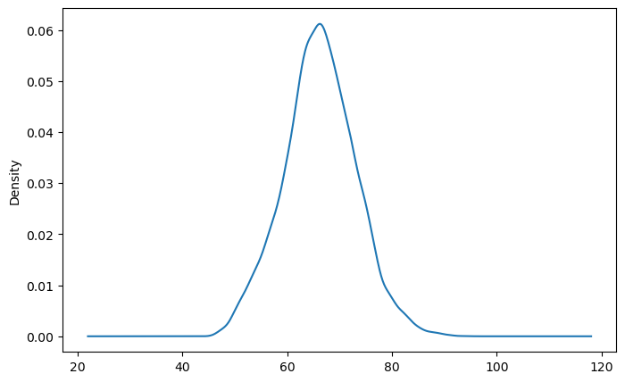

```python
plt.figure(figsize=(8,5))
df['Overall'].plot(kind='kde')
plt.show()
```

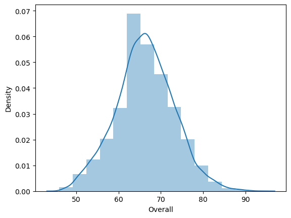

```python
sns.distplot(df['Overall'], kde = True, bins=15)
plt.xlabel("Overall")
plt.show()
```

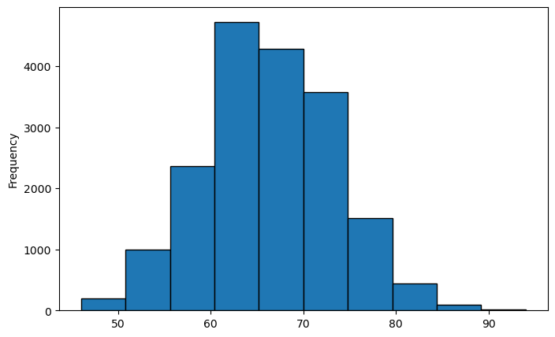

```python
plt.figure(figsize=(8,5))
df['Overall'].plot(kind='hist', edgecolor='black')
plt.show()
```

- From the above distributions we infer that the Overall Rating of the Players Ranges between [50-90].
- Maximum frequency range lies between [60-70].

### 11. Retrieve the "Names" of Top 20 players based on the "Overall" Rating.

```python
top_20_list = df.groupby('Name')['Overall'].max().sort_values(ascending=False).head(20)
dataframe = pd.DataFrame(top_20_list)
dataframe.reset_index()
```

|  | Name | Overall |
| --- | --- | --- |
| 0 | Cristiano Ronaldo | 94 |
| 1 | L. Messi | 94 |
| 2 | Neymar Jr | 92 |
| 3 | Sergio Ramos | 91 |
| 4 | E. Hazard | 91 |
| 5 | De Gea | 91 |
| 6 | L. Suárez | 91 |
| 7 | L. Modrić | 91 |
| 8 | K. De Bruyne | 91 |
| 9 | D. Godín | 90 |
| 10 | David Silva | 90 |
| 11 | T. Kroos | 90 |
| 12 | J. Oblak | 90 |
| 13 | R. Lewandowski | 90 |
| 14 | H. Kane | 89 |
| 15 | T. Courtois | 89 |
| 16 | S. Agüero | 89 |
| 17 | M. ter Stegen | 89 |
| 18 | Sergio Busquets | 89 |
| 19 | E. Cavani | 89 |

#### Other way to find required information from dataset

```python
top20=df.copy()
top20=top20.sort_values(by='Overall',ascending=False)
print(top20[['Name','Overall']].head(20))
```

```
                 Name  Overall
0            L. Messi       94
1   Cristiano Ronaldo       94
2           Neymar Jr       92
3              De Gea       91
4        K. De Bruyne       91
5           E. Hazard       91
6           L. Modrić       91
7           L. Suárez       91
8        Sergio Ramos       91
12           D. Godín       90
13        David Silva       90
9            J. Oblak       90
11           T. Kroos       90
10     R. Lewandowski       90
20    Sergio Busquets       89
24       G. Chiellini       89
23          S. Agüero       89
22           M. Neuer       89
21          E. Cavani       89
16            H. Kane       89
```

### 12. Generate a dataframe which should include all the information of the Top 20 players based on the Overall rating.

```python
top20_info=pd.DataFrame(top20.head(20))
top20_info
```

|  | ID | Name | Age | Nationality | Overall | Potential | Club | Value | Wage | Preferred Foot | International Reputation | Weak Foot | Skill Moves | Work Rate | Position | Joined | Contract Valid Until | Height | Weight | Crossing | Finishing | HeadingAccuracy | ShortPassing | Volleys | Dribbling | Curve | FKAccuracy | LongPassing | BallControl | … |
| --- | --- | --- | --- | --- | --- | --- | --- | --- | --- | --- | --- | --- | --- | --- | --- | --- | --- | --- | --- | --- | --- | --- | --- | --- | --- | --- | --- | --- | --- | --- |
| 0 | 158023 | L. Messi | 31 | Argentina | 94 | 94 | FC Barcelona | 110500000.0 | 565000.0 | Left | 5.0 | 4.0 | 4.0 | Medium/ Medium | RF | 2004 | 2021-01-01 | 5.58 | 159.0 | 84.0 | 95.0 | 70.0 | 90.0 | 86.0 | 97.0 | 93.0 | 94.0 | 87.0 | 96.0 | … |
| 1 | 20801 | Cristiano Ronaldo | 33 | Portugal | 94 | 94 | Juventus | 77000000.0 | 405000.0 | Right | 5.0 | 4.0 | 5.0 | High/ Low | ST | 2018 | 2022-01-01 | 6.17 | 183.0 | 84.0 | 94.0 | 89.0 | 81.0 | 87.0 | 88.0 | 81.0 | 76.0 | 77.0 | 94.0 | … |
| 2 | 190871 | Neymar Jr | 26 | Brazil | 92 | 93 | Paris Saint-Germain | 118500000.0 | 290000.0 | Right | 5.0 | 5.0 | 5.0 | High/ Medium | LW | 2017 | 2022-01-01 | 5.75 | 150.0 | 79.0 | 87.0 | 62.0 | 84.0 | 84.0 | 96.0 | 88.0 | 87.0 | 78.0 | 95.0 | … |
| 3 | 193080 | De Gea | 27 | Spain | 91 | 93 | Manchester United | 72000000.0 | 260000.0 | Right | 4.0 | 3.0 | 1.0 | Medium/ Medium | GK | 2011 | 2020-01-01 | 6.33 | 168.0 | 17.0 | 13.0 | 21.0 | 50.0 | 13.0 | 18.0 | 21.0 | 19.0 | 51.0 | 42.0 | … |
| 4 | 192985 | K. De Bruyne | 27 | Belgium | 91 | 92 | Manchester City | 102000000.0 | 355000.0 | Right | 4.0 | 5.0 | 4.0 | High/ High | RCM | 2015 | 2023-01-01 | 5.92 | 154.0 | 93.0 | 82.0 | 55.0 | 92.0 | 82.0 | 86.0 | 85.0 | 83.0 | 91.0 | 91.0 | … |
| 5 | 183277 | E. Hazard | 27 | Belgium | 91 | 91 | Chelsea | 93000000.0 | 340000.0 | Right | 4.0 | 4.0 | 4.0 | High/ Medium | LF | 2012 | 2020-01-01 | 5.67 | 163.0 | 81.0 | 84.0 | 61.0 | 89.0 | 80.0 | 95.0 | 83.0 | 79.0 | 83.0 | 94.0 | … |
| 6 | 177003 | L. Modrić | 32 | Croatia | 91 | 91 | Real Madrid | 67000000.0 | 420000.0 | Right | 4.0 | 4.0 | 4.0 | High/ High | RCM | 2012 | 2020-01-01 | 5.67 | 146.0 | 86.0 | 72.0 | 55.0 | 93.0 | 76.0 | 90.0 | 85.0 | 78.0 | 88.0 | 93.0 | … |
| 7 | 176580 | L. Suárez | 31 | Uruguay | 91 | 91 | FC Barcelona | 80000000.0 | 455000.0 | Right | 5.0 | 4.0 | 3.0 | High/ Medium | RS | 2014 | 2021-01-01 | 6.00 | 190.0 | 77.0 | 93.0 | 77.0 | 82.0 | 88.0 | 87.0 | 86.0 | 84.0 | 64.0 | 90.0 | … |
| 8 | 155862 | Sergio Ramos | 32 | Spain | 91 | 91 | Real Madrid | 51000000.0 | 380000.0 | Right | 4.0 | 3.0 | 3.0 | High/ Medium | RCB | 2005 | 2020-01-01 | 6.00 | 181.0 | 66.0 | 60.0 | 91.0 | 78.0 | 66.0 | 63.0 | 74.0 | 72.0 | 77.0 | 84.0 | … |
| 12 | 182493 | D. Godín | 32 | Uruguay | 90 | 90 | Atlético Madrid | 44000000.0 | 125000.0 | Right | 3.0 | 3.0 | 2.0 | Medium/ High | CB | 2010 | 2019-01-01 | 6.17 | 172.0 | 55.0 | 42.0 | 92.0 | 79.0 | 47.0 | 53.0 | 49.0 | 51.0 | 70.0 | 76.0 | … |
| 13 | 168542 | David Silva | 32 | Spain | 90 | 90 | Manchester City | 60000000.0 | 285000.0 | Left | 4.0 | 2.0 | 4.0 | High/ Medium | LCM | 2010 | 2020-01-01 | 5.67 | 148.0 | 84.0 | 76.0 | 54.0 | 93.0 | 82.0 | 89.0 | 82.0 | 77.0 | 87.0 | 94.0 | … |
| 9 | 200389 | J. Oblak | 25 | Slovenia | 90 | 93 | Atlético Madrid | 68000000.0 | 94000.0 | Right | 3.0 | 3.0 | 1.0 | Medium/ Medium | GK | 2014 | 2021-01-01 | 6.17 | 192.0 | 13.0 | 11.0 | 15.0 | 29.0 | 13.0 | 12.0 | 13.0 | 14.0 | 26.0 | 16.0 | … |
| 11 | 182521 | T. Kroos | 28 | Germany | 90 | 90 | Real Madrid | 76500000.0 | 355000.0 | Right | 4.0 | 5.0 | 3.0 | Medium/ Medium | LCM | 2014 | 2022-01-01 | 6.00 | 168.0 | 88.0 | 76.0 | 54.0 | 92.0 | 82.0 | 81.0 | 86.0 | 84.0 | 93.0 | 90.0 | … |
| 10 | 188545 | R. Lewandowski | 29 | Poland | 90 | 90 | FC Bayern München | 77000000.0 | 205000.0 | Right | 4.0 | 4.0 | 4.0 | High/ Medium | ST | 2014 | 2021-01-01 | 6.00 | 176.0 | 62.0 | 91.0 | 85.0 | 83.0 | 89.0 | 85.0 | 77.0 | 86.0 | 65.0 | 89.0 | … |
| 20 | 189511 | Sergio Busquets | 29 | Spain | 89 | 89 | FC Barcelona | 51500000.0 | 315000.0 | Right | 4.0 | 3.0 | 3.0 | Medium/ Medium | CDM | 2008 | 2023-01-01 | 6.17 | 168.0 | 62.0 | 67.0 | 68.0 | 89.0 | 44.0 | 80.0 | 66.0 | 68.0 | 82.0 | 88.0 | … |
| 24 | 138956 | G. Chiellini | 33 | Italy | 89 | 89 | Juventus | 27000000.0 | 215000.0 | Left | 4.0 | 3.0 | 2.0 | Medium/ High | LCB | 2005 | 2020-01-01 | 6.17 | 187.0 | 58.0 | 33.0 | 83.0 | 59.0 | 45.0 | 58.0 | 60.0 | 31.0 | 59.0 | 57.0 | … |
| 23 | 153079 | S. Agüero | 30 | Argentina | 89 | 89 | Manchester City | 64500000.0 | 300000.0 | Right | 4.0 | 4.0 | 4.0 | High/ Medium | ST | 2011 | 2021-01-01 | 5.67 | 154.0 | 70.0 | 93.0 | 77.0 | 81.0 | 85.0 | 89.0 | 82.0 | 73.0 | 64.0 | 89.0 | … |
| 22 | 167495 | M. Neuer | 32 | Germany | 89 | 89 | FC Bayern München | 38000000.0 | 130000.0 | Right | 5.0 | 4.0 | 1.0 | Medium/ Medium | GK | 2011 | 2021-01-01 | 6.33 | 203.0 | 15.0 | 13.0 | 25.0 | 55.0 | 11.0 | 30.0 | 14.0 | 11.0 | 59.0 | 48.0 | … |
| 21 | 179813 | E. Cavani | 31 | Uruguay | 89 | 89 | Paris Saint-Germain | 60000000.0 | 200000.0 | Right | 4.0 | 4.0 | 3.0 | High/ High | LS | 2013 | 2020-01-01 | 6.08 | 170.0 | 70.0 | 89.0 | 89.0 | 78.0 | 90.0 | 80.0 | 77.0 | 76.0 | 52.0 | 82.0 | … |
| 16 | 202126 | H. Kane | 24 | England | 89 | 91 | Tottenham Hotspur | 83500000.0 | 205000.0 | Right | 3.0 | 4.0 | 3.0 | High/ High | ST | 2010 | 2024-01-01 | 6.17 | 196.0 | 75.0 | 94.0 | 85.0 | 80.0 | 84.0 | 80.0 | 78.0 | 68.0 | 82.0 | 84.0 | … |

### 13. What is the average "Age" and "Wage" of these top 20 players?

(Use the data frame created in the Question 11)

```python
avg = df_list[['Age', 'Wage']].mean()


df_avg = pd.DataFrame(avg)
df_avg.T
```

|  | Age | Wage |
| --- | --- | --- |
| 0 | 28.9 | 301700.0 |

#### Other way to find required information from dataset

```python
Avg_age = (df_list['Age'].mean())
Avg_wage = (df_list['Wage'].mean())

print("Average Age : ",Avg_age,"yrs")
print("Average Wage : €",Avg_wage)
```

```
Average Age :  28.9 yrs
Average Wage : € 301700.0
```

- The average age of the top 20 players in around 30.
- The average wages given to the top 20 players is around € 301700.0.

### 14. Among the top 20 players based on the Overall rating, which player has the highest wage? Display the name of the player with his wage.

```python
df_maxwage = df_list[['Wage']].idxmax()
df.loc[df_maxwage, ['Name', 'Wage']]
```

|  | Name | Wage |
| --- | --- | --- |
| 0 | L. Messi | 565000.0 |

#### Other way to find required information from dataset

```python
df_list.sort_values(by=['Wage','Overall'],axis=0,ascending=[False,False],inplace=False,kind='quicksort', na_position='first', ignore_index=True, key=None)
print(top20_info[['Name','Wage']].head(1))
```

```
       Name      Wage
0  L. Messi  565000.0
```

### 15. Generate a dataframe which should include the "Player Name", "Club Name", "Wage", and "Overall Rating".

i) Find the average Overall rating for each club.  
ii) Display the average overall rating of Top10 Clubs using a plot

```python
df_list1 = df.loc[:, ['Name', 'Club', 'Wage', 'Overall']]
df_list1.head()
```

|  | Name | Club | Wage | Overall |
| --- | --- | --- | --- | --- |
| 0 | L. Messi | FC Barcelona | 565000.0 | 94 |
| 1 | Cristiano Ronaldo | Juventus | 405000.0 | 94 |
| 2 | Neymar Jr | Paris Saint-Germain | 290000.0 | 92 |
| 3 | De Gea | Manchester United | 260000.0 | 91 |
| 4 | K. De Bruyne | Manchester City | 355000.0 | 91 |

**Average Overall Rating for Each Club -**

```python
rating = df_list1.groupby('Club')['Overall'].mean().sort_values(ascending=False)
df_rating = pd.DataFrame(rating)
df_rating.reset_index()
```

|  | Club | Overall |
| --- | --- | --- |
| 0 | Juventus | 82.280000 |
| 1 | Napoli | 80.000000 |
| 2 | Inter | 79.750000 |
| 3 | Real Madrid | 78.242424 |
| 4 | Milan | 78.074074 |
| 5 | FC Barcelona | 78.030303 |
| 6 | Paris Saint-Germain | 77.433333 |
| 7 | Roma | 77.423077 |
| 8 | Manchester United | 77.242424 |
| 9 | SL Benfica | 77.000000 |
| 10 | FC Bayern München | 77.000000 |
| 11 | Chelsea | 76.787879 |
| 12 | Manchester City | 76.727273 |
| 13 | Tottenham Hotspur | 76.696970 |
| 14 | FC Porto | 76.678571 |
| 15 | Sporting CP | 76.133333 |
| 16 | Liverpool | 76.000000 |
| 17 | Bayer 04 Leverkusen | 75.807692 |
| 18 | Lazio | 75.437500 |
| 19 | Borussia Dortmund | 75.333333 |
| 20 | Sevilla FC | 75.200000 |
| 21 | Real Betis | 75.185185 |
| 22 | Arsenal | 75.181818 |
| 23 | Atlético Madrid | 75.060606 |
| 24 | SC Braga | 74.821429 |
| 25 | Valencia CF | 74.696970 |
| 26 | Villarreal CF | 74.343750 |
| 27 | FC Schalke 04 | 74.310345 |
| 28 | Everton | 74.121212 |
| 29 | Leicester City | 73.843750 |

[output cut: 621 more lines]

**Average Overall Rating of the Top 10 Clubs using Barplot -**

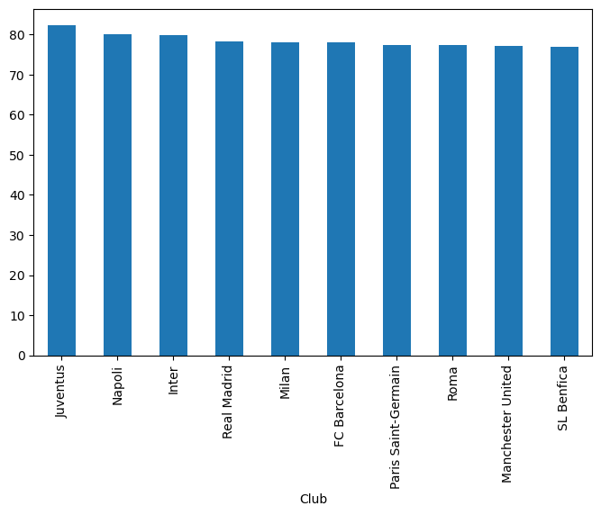

```python
plt.figure(figsize=(8,5))
club_rating = rating.head(10)
club_rating.plot(kind='bar')
plt.show()
```

```python
#Average Overall Rating of the Top 10 Clubs
print (club_rating)
```

```
Club
Juventus               82.280000
Napoli                 80.000000
Inter                  79.750000
Real Madrid            78.242424
Milan                  78.074074
FC Barcelona           78.030303
Paris Saint-Germain    77.433333
Roma                   77.423077
Manchester United      77.242424
SL Benfica             77.000000
Name: Overall, dtype: float64
```

### 16. What is the relationship between age and individual potential of the player? Visualize the relationship with appropriate plot and Comment on the same.

```python
corr_Ap = df[[ 'Age', 'Potential']].corr()
corr_Ap
```

|  | Age | Potential |
| --- | --- | --- |
| Age | 1.000000 | -0.253312 |
| Potential | -0.253312 | 1.000000 |

```python
df_Age_Pot_cor = df['Age'].corr(df['Potential'])
print("Correlation between Age and Potential is ", round(df_Age_Pot_cor,2))
```

```
Correlation between Age and Potential is  -0.25
```

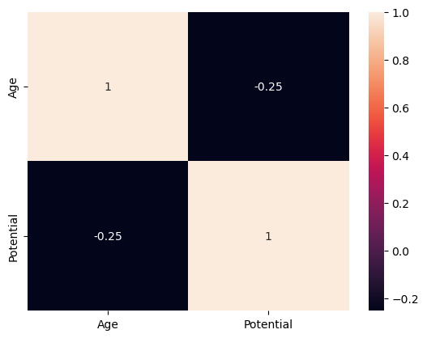

```python
sns.heatmap( corr_Ap, annot= True )
plt.show()
```

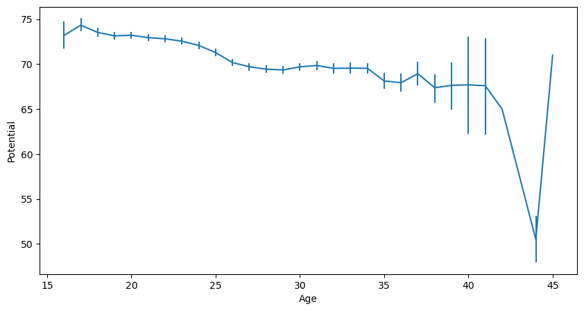

```python
# Visualize the relationship with appropriate plot
plt.figure(figsize=(10,5))
sns.lineplot(x='Age', y='Potential', data=df,  errorbar='ci', err_style='bars')
plt.show()
```

- From the above we infer that the "Highest Potential" of the Players is between Ages of 16 to 22 and after which it decreases gradually till the Age of 40.
- After the Age of 40 there is a steep decline in the "Player’s Potential".
- We can also derive that the relationship between the "Players Age" and the "Player’s Potential" is Inversely Proportional.

### 17. Which features directly contribute to the wages of the players? Support your answer with a plot and a metric.

- Use Potential, Overall, Value, International Reputation, and Release Clause

```python
df[['Potential', 'Overall', 'Value', 'International Reputation', 'Release Clause', 'Wage', 'Age']].cov()
```

|  | Potential | Overall | Value | International Reputation | Release Clause | Wage | Age |
| --- | --- | --- | --- | --- | --- | --- | --- |
| Potential | 3.765658e+01 | 2.802156e+01 | 1.978346e+07 | 9.005379e-01 | 3.615364e+07 | 6.566507e+04 | -7.259186e+00 |
| Overall | 2.802156e+01 | 4.773331e+01 | 2.423998e+07 | 1.358576e+00 | 4.366496e+07 | 8.692792e+04 | 1.459474e+01 |
| Value | 1.978346e+07 | 2.423998e+07 | 3.130327e+13 | 1.438433e+06 | 5.791542e+13 | 1.056609e+11 | 1.960181e+06 |
| International Reputation | 9.005379e-01 | 1.358576e+00 | 1.438433e+06 | 1.548846e-01 | 2.603235e+06 | 5.789708e+03 | 4.658214e-01 |
| Release Clause | 3.615364e+07 | 4.366496e+07 | 5.791542e+13 | 2.603235e+06 | 1.139595e+14 | 1.933141e+11 | 3.244062e+06 |
| Wage | 6.566507e+04 | 8.692792e+04 | 1.056609e+11 | 5.789708e+03 | 1.933141e+11 | 4.839688e+08 | 1.450059e+04 |
| Age | -7.259186e+00 | 1.459474e+01 | 1.960181e+06 | 4.658214e-01 | 3.244062e+06 | 1.450059e+04 | 2.180836e+01 |

```python
data_corr = df[['Potential', 'Overall', 'Value', 'International Reputation', 'Release Clause', 'Wage', 'Age']].corr()
data_corr
```

|  | Potential | Overall | Value | International Reputation | Release Clause | Wage | Age |
| --- | --- | --- | --- | --- | --- | --- | --- |
| Potential | 1.000000 | 0.660939 | 0.576218 | 0.372887 | 0.551895 | 0.486413 | -0.253312 |
| Overall | 0.660939 | 1.000000 | 0.627085 | 0.499654 | 0.592035 | 0.571926 | 0.452350 |
| Value | 0.576218 | 0.627085 | 1.000000 | 0.653267 | 0.969670 | 0.858442 | 0.075022 |
| International Reputation | 0.372887 | 0.499654 | 0.653267 | 1.000000 | 0.619632 | 0.668719 | 0.253457 |
| Release Clause | 0.551895 | 0.592035 | 0.969670 | 0.619632 | 1.000000 | 0.823151 | 0.065073 |
| Wage | 0.486413 | 0.571926 | 0.858442 | 0.668719 | 0.823151 | 1.000000 | 0.141145 |
| Age | -0.253312 | 0.452350 | 0.075022 | 0.253457 | 0.065073 | 0.141145 | 1.000000 |

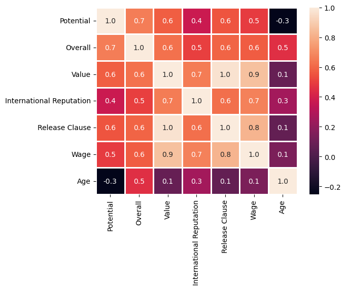

```python
sns.heatmap(data_corr, annot=True, fmt=".1f", linewidth=1)
plt.show()
```

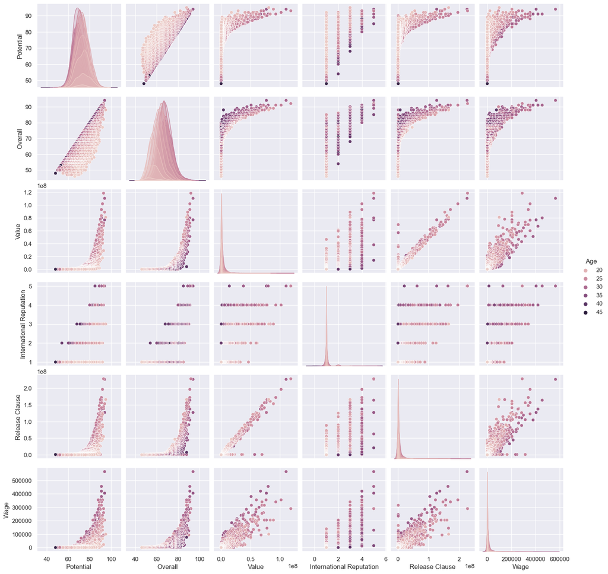

```python
sns.set()
sns.pairplot(df[['Potential', 'Overall', 'Value', 'International Reputation', 'Release Clause', 'Wage', 'Age']], hue='Age')
plt.show()
```

- "Wage" has a Positive Correlation with Potential, Overall, Value, International Reputation, and Release Clause.
- Therefore, when the "Wage" is higher or lower, the other variables move in similar direction.
- "Wage" and "Age" indicate a minimal relationship.

### 18. Find the position in the pitch where the maximum number of players play and the position where the minimum number of players play? Display it using a plot.

```python
max_position = df['Position'].value_counts().sort_values(ascending=False).head(1)
print('Maximum Position of Players = ')
df_max_position = pd.DataFrame(max_position)
df_max_position.reset_index()
```

```
Maximum Position of Players =
```

|  | index | Position |
| --- | --- | --- |
| 0 | ST | 2212 |

```python
min_position = df['Position'].value_counts().sort_values(ascending=True).head(1)
print('Minimum Position of Players = ')
df_min_position = pd.DataFrame(min_position)
df_min_position.reset_index()
```

```
Minimum Position of Players =
```

|  | index | Position |
| --- | --- | --- |
| 0 | LF | 15 |

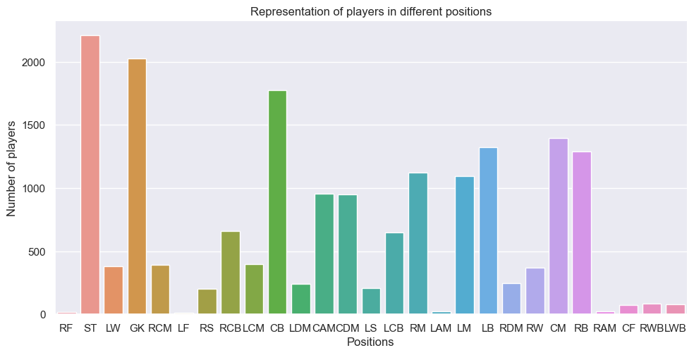

```python
sns.catplot(data=df, x="Position", kind="count", aspect=2)
plt.xlabel("Positions")
plt.ylabel("Number of players")
plt.title("Representation of players in different positions")

plt.show()
```

### 19. How many players are from the club 'Juventus' and the wage is greater than 200K? Display all the information of such players.

```python
Fifa_Juve = np.where((df['Club']=='Juventus') & (df['Wage']>200000))

Fifa_juve_filter = df.loc[Fifa_Juve]

print(str(Fifa_juve_filter['Club'].count()) + " Players in Juventus Club with wages greater than 200k")
```

```
3 Players in Juventus Club with wages greater than 200k
```

#### Other way to get required information

```python
df[(df['Club'] == 'Juventus') & (df['Wage'] > 200000)].reset_index()
```

|  | index | ID | Name | Age | Nationality | Overall | Potential | Club | Value | Wage | Preferred Foot | International Reputation | Weak Foot | Skill Moves | Work Rate | Position | Joined | Contract Valid Until | Height | Weight | Crossing | Finishing | HeadingAccuracy | ShortPassing | Volleys | Dribbling | Curve | FKAccuracy | LongPassing | … |
| --- | --- | --- | --- | --- | --- | --- | --- | --- | --- | --- | --- | --- | --- | --- | --- | --- | --- | --- | --- | --- | --- | --- | --- | --- | --- | --- | --- | --- | --- | --- |
| 0 | 1 | 20801 | Cristiano Ronaldo | 33 | Portugal | 94 | 94 | Juventus | 77000000.0 | 405000.0 | Right | 5.0 | 4.0 | 5.0 | High/ Low | ST | 2018 | 2022-01-01 | 6.17 | 183.0 | 84.0 | 94.0 | 89.0 | 81.0 | 87.0 | 88.0 | 81.0 | 76.0 | 77.0 | … |
| 1 | 15 | 211110 | P. Dybala | 24 | Argentina | 89 | 94 | Juventus | 89000000.0 | 205000.0 | Left | 3.0 | 3.0 | 4.0 | High/ Medium | LF | 2015 | 2022-01-01 | 5.83 | 165.0 | 82.0 | 84.0 | 68.0 | 87.0 | 88.0 | 92.0 | 88.0 | 88.0 | 75.0 | … |
| 2 | 24 | 138956 | G. Chiellini | 33 | Italy | 89 | 89 | Juventus | 27000000.0 | 215000.0 | Left | 4.0 | 3.0 | 2.0 | Medium/ High | LCB | 2005 | 2020-01-01 | 6.17 | 187.0 | 58.0 | 33.0 | 83.0 | 59.0 | 45.0 | 58.0 | 60.0 | 31.0 | 59.0 | … |

### 20. Generate a data frame containing top 5 players by Overall rating for each unique position.

```python
#Player Positions
df['Position'].unique()
```

```
array(['RF', 'ST', 'LW', 'GK', 'RCM', 'LF', 'RS', 'RCB', 'LCM', 'CB',
       'LDM', 'CAM', 'CDM', 'LS', 'LCB', 'RM', 'LAM', 'LM', 'LB', 'RDM',
       'RW', 'CM', 'RB', 'RAM', 'CF', 'RWB', 'LWB'], dtype=object)
```

```python
#Number of different positions
df['Position'].nunique()
```

```
27
```

#### top 5 players by Overall rating for each unique position (Overall information in output)

```python
top5_unique_pos = df.groupby(by = ['Position']).apply(lambda x: x.sort_values('Overall', ascending = False).head(5))

display(top5_unique_pos)
```

| Position |  | ID | Name | Age | Nationality | Overall | Potential | Club | Value | Wage | Preferred Foot | International Reputation | Weak Foot | Skill Moves | Work Rate | Position | Joined | Contract Valid Until | Height | Weight | Crossing | Finishing | HeadingAccuracy | ShortPassing | Volleys | Dribbling | Curve | FKAccuracy | LongPassing | … |
| --- | --- | --- | --- | --- | --- | --- | --- | --- | --- | --- | --- | --- | --- | --- | --- | --- | --- | --- | --- | --- | --- | --- | --- | --- | --- | --- | --- | --- | --- | --- |
| CAM | 17 | 194765 | A. Griezmann | 27 | France | 89 | 90 | Atlético Madrid | 78000000.0 | 145000.0 | Left | 4.0 | 3.0 | 4.0 | High/ High | CAM | 2014 | 2023-01-01 | 5.75 | 161.0 | 82.0 | 90.0 | 84.0 | 83.0 | 87.0 | 88.0 | 84.0 | 78.0 | 76.0 | … |
|  | 31 | 190460 | C. Eriksen | 26 | Denmark | 88 | 91 | Tottenham Hotspur | 73500000.0 | 205000.0 | Right | 3.0 | 5.0 | 4.0 | High/ Medium | CAM | 2013 | 2020-01-01 | 5.92 | 168.0 | 88.0 | 80.0 | 52.0 | 91.0 | 77.0 | 84.0 | 86.0 | 87.0 | 88.0 | … |
|  | 61 | 201942 | Roberto Firmino | 26 | Brazil | 86 | 87 | Liverpool | 53000000.0 | 195000.0 | Right | 3.0 | 4.0 | 4.0 | High/ High | CAM | 2015 | 2023-01-01 | 5.92 | 168.0 | 72.0 | 87.0 | 77.0 | 86.0 | 81.0 | 87.0 | 80.0 | 65.0 | 75.0 | … |
|  | 66 | 189596 | T. Müller | 28 | Germany | 86 | 86 | FC Bayern München | 45000000.0 | 135000.0 | Right | 4.0 | 4.0 | 3.0 | High/ High | CAM | 2008 | 2021-01-01 | 6.08 | 165.0 | 79.0 | 87.0 | 82.0 | 83.0 | 84.0 | 75.0 | 81.0 | 59.0 | 72.0 | … |
|  | 74 | 176635 | M. Özil | 29 | Germany | 86 | 86 | Arsenal | 43500000.0 | 190000.0 | Left | 4.0 | 2.0 | 4.0 | Medium/ Low | CAM | 2013 | 2021-01-01 | 5.92 | 168.0 | 83.0 | 73.0 | 54.0 | 89.0 | 80.0 | 84.0 | 84.0 | 77.0 | 82.0 | … |
| CB | 12 | 182493 | D. Godín | 32 | Uruguay | 90 | 90 | Atlético Madrid | 44000000.0 | 125000.0 | Right | 3.0 | 3.0 | 2.0 | Medium/ High | CB | 2010 | 2019-01-01 | 6.17 | 172.0 | 55.0 | 42.0 | 92.0 | 79.0 | 47.0 | 53.0 | 49.0 | 51.0 | 70.0 | … |
|  | 42 | 205600 | S. Umtiti | 24 | France | 87 | 92 | FC Barcelona | 57000000.0 | 205000.0 | Left | 3.0 | 3.0 | 2.0 | Medium/ High | CB | 2016 | 2023-01-01 | 6.00 | 165.0 | 69.0 | 51.0 | 79.0 | 81.0 | 70.0 | 69.0 | 72.0 | 62.0 | 73.0 | … |
|  | 73 | 177509 | M. Benatia | 31 | Morocco | 86 | 86 | Juventus | 30000000.0 | 160000.0 | Right | 3.0 | 3.0 | 2.0 | Medium/ High | CB | 2014 | 2020-01-01 | 6.17 | 207.0 | 45.0 | 47.0 | 83.0 | 65.0 | 44.0 | 64.0 | 34.0 | 27.0 | 65.0 | … |
|  | 89 | 192366 | N. Otamendi | 30 | Argentina | 85 | 85 | Manchester City | 28500000.0 | 170000.0 | Right | 3.0 | 3.0 | 2.0 | High/ High | CB | 2015 | 2022-01-01 | 6.00 | 179.0 | 52.0 | 54.0 | 85.0 | 75.0 | 57.0 | 51.0 | 50.0 | 39.0 | 72.0 | … |
|  | 102 | 171919 | Naldo | 35 | Brazil | 85 | 85 | FC Schalke 04 | 9000000.0 | 38000.0 | Right | 3.0 | 4.0 | 2.0 | Medium/ Medium | CB | 2016 | 2020-01-01 | 6.50 | 201.0 | 45.0 | 57.0 | 94.0 | 76.0 | 60.0 | 60.0 | 52.0 | 76.0 | 70.0 | … |
| CDM | 20 | 189511 | Sergio Busquets | 29 | Spain | 89 | 89 | FC Barcelona | 51500000.0 | 315000.0 | Right | 4.0 | 3.0 | 3.0 | Medium/ Medium | CDM | 2008 | 2023-01-01 | 6.17 | 168.0 | 62.0 | 67.0 | 68.0 | 89.0 | 44.0 | 80.0 | 66.0 | 68.0 | 82.0 | … |
|  | 27 | 200145 | Casemiro | 26 | Brazil | 88 | 90 | Real Madrid | 59500000.0 | 285000.0 | Right | 3.0 | 3.0 | 2.0 | Medium/ High | CDM | 2013 | 2021-01-01 | 6.08 | 185.0 | 52.0 | 59.0 | 76.0 | 85.0 | 53.0 | 69.0 | 59.0 | 74.0 | 82.0 | … |
|  | 72 | 180206 | M. Pjanić | 28 | Bosnia Herzegovina | 86 | 86 | Juventus | 44000000.0 | 180000.0 | Right | 3.0 | 4.0 | 3.0 | Medium/ Medium | CDM | 2016 | 2023-01-01 | 5.83 | 159.0 | 80.0 | 60.0 | 60.0 | 89.0 | 72.0 | 86.0 | 86.0 | 92.0 | 85.0 | … |
|  | 75 | 135507 | Fernandinho | 33 | Brazil | 86 | 86 | Manchester City | 18000000.0 | 185000.0 | Right | 3.0 | 4.0 | 3.0 | Medium/ High | CDM | 2013 | 2020-01-01 | 5.83 | 148.0 | 68.0 | 69.0 | 63.0 | 85.0 | 74.0 | 77.0 | 70.0 | 72.0 | 81.0 | … |
|  | 118 | 209499 | Fabinho | 24 | Brazil | 84 | 88 | Liverpool | 34000000.0 | 120000.0 | Right | 3.0 | 2.0 | 3.0 | Medium/ Medium | CDM | 2018 | 2023-01-01 | 6.17 | 172.0 | 79.0 | 66.0 | 75.0 | 83.0 | 47.0 | 76.0 | 71.0 | 53.0 | 78.0 | … |
| CF | 271 | 198706 | Luis Alberto | 25 | Spain | 82 | 85 | Lazio | 28500000.0 | 67000.0 | Right | 2.0 | 3.0 | 4.0 | High/ Medium | CF | 2016 | 2022-01-01 | 6.00 | 163.0 | 76.0 | 80.0 | 49.0 | 88.0 | 76.0 | 86.0 | 86.0 | 81.0 | 87.0 | … |
|  | 293 | 184431 | S. Giovinco | 31 | Italy | 82 | 82 | Toronto FC | 20000000.0 | 15000.0 | Right | 2.0 | 4.0 | 4.0 | High/ Medium | CF | 2015 | 2019-01-01 | 5.33 | 134.0 | 72.0 | 80.0 | 34.0 | 80.0 | 75.0 | 86.0 | 90.0 | 93.0 | 76.0 | … |
|  | 350 | 205175 | A. Milik | 24 | Poland | 81 | 88 | Napoli | 25500000.0 | 71000.0 | Left | 3.0 | 3.0 | 4.0 | Medium/ Medium | CF | 2016 | 2021-01-01 | 6.08 | 172.0 | 58.0 | 88.0 | 78.0 | 63.0 | 76.0 | 74.0 | 71.0 | 74.0 | 62.0 | … |
|  | 382 | 187072 | L. Stindl | 29 | Germany | 81 | 81 | Borussia Mönchengladbach | 18000000.0 | 43000.0 | Right | 2.0 | 4.0 | 4.0 | Medium/ Medium | CF | 2015 | 2021-01-01 | 5.92 | 176.0 | 76.0 | 79.0 | 64.0 | 85.0 | 86.0 | 78.0 | 79.0 | 69.0 | 69.0 | … |
|  | 407 | 144622 | Raffael | 33 | Brazil | 81 | 81 | Borussia Mönchengladbach | 11000000.0 | 41000.0 | Right | 2.0 | 4.0 | 4.0 | High/ Medium | CF | 2013 | 2019-01-01 | 5.75 | 152.0 | 78.0 | 78.0 | 63.0 | 83.0 | 83.0 | 87.0 | 79.0 | 77.0 | 76.0 | … |
| CM | 67 | 189509 | Thiago | 27 | Spain | 86 | 86 | FC Bayern München | 45500000.0 | 130000.0 | Right | 3.0 | 3.0 | 5.0 | Medium/ Medium | CM | 2013 | 2021-01-01 | 5.75 | 154.0 | 72.0 | 69.0 | 54.0 | 90.0 | 90.0 | 90.0 | 85.0 | 77.0 | 87.0 | … |
|  | 78 | 223848 | S. Milinković-Savić | 23 | Serbia | 85 | 90 | Lazio | 50500000.0 | 73000.0 | Right | 2.0 | 4.0 | 4.0 | High/ Medium | CM | 2015 | 2023-01-01 | 6.25 | 168.0 | 64.0 | 80.0 | 86.0 | 85.0 | 74.0 | 86.0 | 78.0 | 75.0 | 85.0 | … |
|  | 121 | 205498 | Jorginho | 26 | Italy | 84 | 87 | Chelsea | 38000000.0 | 155000.0 | Right | 2.0 | 3.0 | 3.0 | Medium/ Medium | CM | 2018 | 2023-01-01 | 5.92 | 148.0 | 75.0 | 57.0 | 56.0 | 89.0 | 71.0 | 82.0 | 75.0 | 76.0 | 87.0 | … |
|  | 136 | 186942 | I. Gündoğan | 27 | Germany | 84 | 84 | Manchester City | 32000000.0 | 175000.0 | Right | 3.0 | 4.0 | 4.0 | High/ Medium | CM | 2016 | 2020-01-01 | 5.92 | 176.0 | 74.0 | 73.0 | 50.0 | 88.0 | 75.0 | 85.0 | 81.0 | 74.0 | 83.0 | … |
|  | 161 | 220971 | N. Keïta | 23 | Guinea | 83 | 88 | Liverpool | 34000000.0 | 120000.0 | Right | 2.0 | 4.0 | 4.0 | High/ Medium | CM | 2018 | 2023-01-01 | 5.67 | 141.0 | 62.0 | 74.0 | 42.0 | 88.0 | 71.0 | 88.0 | 64.0 | 70.0 | 78.0 | … |
| GK | 3 | 193080 | De Gea | 27 | Spain | 91 | 93 | Manchester United | 72000000.0 | 260000.0 | Right | 4.0 | 3.0 | 1.0 | Medium/ Medium | GK | 2011 | 2020-01-01 | 6.33 | 168.0 | 17.0 | 13.0 | 21.0 | 50.0 | 13.0 | 18.0 | 21.0 | 19.0 | 51.0 | … |
|  | 9 | 200389 | J. Oblak | 25 | Slovenia | 90 | 93 | Atlético Madrid | 68000000.0 | 94000.0 | Right | 3.0 | 3.0 | 1.0 | Medium/ Medium | GK | 2014 | 2021-01-01 | 6.17 | 192.0 | 13.0 | 11.0 | 15.0 | 29.0 | 13.0 | 12.0 | 13.0 | 14.0 | 26.0 | … |
|  | 18 | 192448 | M. ter Stegen | 26 | Germany | 89 | 92 | FC Barcelona | 58000000.0 | 240000.0 | Right | 3.0 | 4.0 | 1.0 | Medium/ Medium | GK | 2014 | 2022-01-01 | 6.17 | 187.0 | 15.0 | 14.0 | 11.0 | 36.0 | 14.0 | 17.0 | 18.0 | 12.0 | 42.0 | … |
|  | 19 | 192119 | T. Courtois | 26 | Belgium | 89 | 90 | Real Madrid | 53500000.0 | 240000.0 | Left | 4.0 | 2.0 | 1.0 | Medium/ Medium | GK | 2018 | 2024-01-01 | 6.50 | 212.0 | 14.0 | 14.0 | 13.0 | 33.0 | 12.0 | 13.0 | 19.0 | 20.0 | 35.0 | … |
|  | 22 | 167495 | M. Neuer | 32 | Germany | 89 | 89 | FC Bayern München | 38000000.0 | 130000.0 | Right | 5.0 | 4.0 | 1.0 | Medium/ Medium | GK | 2011 | 2021-01-01 | 6.33 | 203.0 | 15.0 | 13.0 | 25.0 | 55.0 | 11.0 | 30.0 | 14.0 | 11.0 | 59.0 | … |

[output cut: 105 more lines]

#### top 5 players by Overall rating for each unique position (Postion-wise differnt output )

```python
st = top5_unique_pos[top5_unique_pos['Position']=='ST']
display(st)
```

| Position |  | ID | Name | Age | Nationality | Overall | Potential | Club | Value | Wage | Preferred Foot | International Reputation | Weak Foot | Skill Moves | Work Rate | Position | Joined | Contract Valid Until | Height | Weight | Crossing | Finishing | HeadingAccuracy | ShortPassing | Volleys | Dribbling | Curve | FKAccuracy | LongPassing | … |
| --- | --- | --- | --- | --- | --- | --- | --- | --- | --- | --- | --- | --- | --- | --- | --- | --- | --- | --- | --- | --- | --- | --- | --- | --- | --- | --- | --- | --- | --- | --- |
| ST | 1 | 20801 | Cristiano Ronaldo | 33 | Portugal | 94 | 94 | Juventus | 77000000.0 | 405000.0 | Right | 5.0 | 4.0 | 5.0 | High/ Low | ST | 2018 | 2022-01-01 | 6.17 | 183.0 | 84.0 | 94.0 | 89.0 | 81.0 | 87.0 | 88.0 | 81.0 | 76.0 | 77.0 | … |
|  | 10 | 188545 | R. Lewandowski | 29 | Poland | 90 | 90 | FC Bayern München | 77000000.0 | 205000.0 | Right | 4.0 | 4.0 | 4.0 | High/ Medium | ST | 2014 | 2021-01-01 | 6.00 | 176.0 | 62.0 | 91.0 | 85.0 | 83.0 | 89.0 | 85.0 | 77.0 | 86.0 | 65.0 | … |
|  | 16 | 202126 | H. Kane | 24 | England | 89 | 91 | Tottenham Hotspur | 83500000.0 | 205000.0 | Right | 3.0 | 4.0 | 3.0 | High/ High | ST | 2010 | 2024-01-01 | 6.17 | 196.0 | 75.0 | 94.0 | 85.0 | 80.0 | 84.0 | 80.0 | 78.0 | 68.0 | 82.0 | … |
|  | 23 | 153079 | S. Agüero | 30 | Argentina | 89 | 89 | Manchester City | 64500000.0 | 300000.0 | Right | 4.0 | 4.0 | 4.0 | High/ Medium | ST | 2011 | 2021-01-01 | 5.67 | 154.0 | 70.0 | 93.0 | 77.0 | 81.0 | 85.0 | 89.0 | 82.0 | 73.0 | 64.0 | … |
|  | 36 | 173731 | G. Bale | 28 | Wales | 88 | 88 | Real Madrid | 60000000.0 | 355000.0 | Left | 4.0 | 3.0 | 4.0 | High/ Medium | ST | 2013 | 2022-01-01 | 6.08 | 181.0 | 87.0 | 86.0 | 84.0 | 85.0 | 85.0 | 87.0 | 90.0 | 87.0 | 80.0 | … |

```python
cam = top5_unique_pos[top5_unique_pos['Position']=='CAM']
display(cam)
```

| Position |  | ID | Name | Age | Nationality | Overall | Potential | Club | Value | Wage | Preferred Foot | International Reputation | Weak Foot | Skill Moves | Work Rate | Position | Joined | Contract Valid Until | Height | Weight | Crossing | Finishing | HeadingAccuracy | ShortPassing | Volleys | Dribbling | Curve | FKAccuracy | LongPassing | … |
| --- | --- | --- | --- | --- | --- | --- | --- | --- | --- | --- | --- | --- | --- | --- | --- | --- | --- | --- | --- | --- | --- | --- | --- | --- | --- | --- | --- | --- | --- | --- |
| CAM | 17 | 194765 | A. Griezmann | 27 | France | 89 | 90 | Atlético Madrid | 78000000.0 | 145000.0 | Left | 4.0 | 3.0 | 4.0 | High/ High | CAM | 2014 | 2023-01-01 | 5.75 | 161.0 | 82.0 | 90.0 | 84.0 | 83.0 | 87.0 | 88.0 | 84.0 | 78.0 | 76.0 | … |
|  | 31 | 190460 | C. Eriksen | 26 | Denmark | 88 | 91 | Tottenham Hotspur | 73500000.0 | 205000.0 | Right | 3.0 | 5.0 | 4.0 | High/ Medium | CAM | 2013 | 2020-01-01 | 5.92 | 168.0 | 88.0 | 80.0 | 52.0 | 91.0 | 77.0 | 84.0 | 86.0 | 87.0 | 88.0 | … |
|  | 61 | 201942 | Roberto Firmino | 26 | Brazil | 86 | 87 | Liverpool | 53000000.0 | 195000.0 | Right | 3.0 | 4.0 | 4.0 | High/ High | CAM | 2015 | 2023-01-01 | 5.92 | 168.0 | 72.0 | 87.0 | 77.0 | 86.0 | 81.0 | 87.0 | 80.0 | 65.0 | 75.0 | … |
|  | 66 | 189596 | T. Müller | 28 | Germany | 86 | 86 | FC Bayern München | 45000000.0 | 135000.0 | Right | 4.0 | 4.0 | 3.0 | High/ High | CAM | 2008 | 2021-01-01 | 6.08 | 165.0 | 79.0 | 87.0 | 82.0 | 83.0 | 84.0 | 75.0 | 81.0 | 59.0 | 72.0 | … |
|  | 74 | 176635 | M. Özil | 29 | Germany | 86 | 86 | Arsenal | 43500000.0 | 190000.0 | Left | 4.0 | 2.0 | 4.0 | Medium/ Low | CAM | 2013 | 2021-01-01 | 5.92 | 168.0 | 83.0 | 73.0 | 54.0 | 89.0 | 80.0 | 84.0 | 84.0 | 77.0 | 82.0 | … |

```python
cb = top5_unique_pos[top5_unique_pos['Position']=='CB']
display(cb)
```

| Position |  | ID | Name | Age | Nationality | Overall | Potential | Club | Value | Wage | Preferred Foot | International Reputation | Weak Foot | Skill Moves | Work Rate | Position | Joined | Contract Valid Until | Height | Weight | Crossing | Finishing | HeadingAccuracy | ShortPassing | Volleys | Dribbling | Curve | FKAccuracy | LongPassing | … |
| --- | --- | --- | --- | --- | --- | --- | --- | --- | --- | --- | --- | --- | --- | --- | --- | --- | --- | --- | --- | --- | --- | --- | --- | --- | --- | --- | --- | --- | --- | --- |
| CB | 12 | 182493 | D. Godín | 32 | Uruguay | 90 | 90 | Atlético Madrid | 44000000.0 | 125000.0 | Right | 3.0 | 3.0 | 2.0 | Medium/ High | CB | 2010 | 2019-01-01 | 6.17 | 172.0 | 55.0 | 42.0 | 92.0 | 79.0 | 47.0 | 53.0 | 49.0 | 51.0 | 70.0 | … |
|  | 42 | 205600 | S. Umtiti | 24 | France | 87 | 92 | FC Barcelona | 57000000.0 | 205000.0 | Left | 3.0 | 3.0 | 2.0 | Medium/ High | CB | 2016 | 2023-01-01 | 6.00 | 165.0 | 69.0 | 51.0 | 79.0 | 81.0 | 70.0 | 69.0 | 72.0 | 62.0 | 73.0 | … |
|  | 73 | 177509 | M. Benatia | 31 | Morocco | 86 | 86 | Juventus | 30000000.0 | 160000.0 | Right | 3.0 | 3.0 | 2.0 | Medium/ High | CB | 2014 | 2020-01-01 | 6.17 | 207.0 | 45.0 | 47.0 | 83.0 | 65.0 | 44.0 | 64.0 | 34.0 | 27.0 | 65.0 | … |
|  | 89 | 192366 | N. Otamendi | 30 | Argentina | 85 | 85 | Manchester City | 28500000.0 | 170000.0 | Right | 3.0 | 3.0 | 2.0 | High/ High | CB | 2015 | 2022-01-01 | 6.00 | 179.0 | 52.0 | 54.0 | 85.0 | 75.0 | 57.0 | 51.0 | 50.0 | 39.0 | 72.0 | … |
|  | 102 | 171919 | Naldo | 35 | Brazil | 85 | 85 | FC Schalke 04 | 9000000.0 | 38000.0 | Right | 3.0 | 4.0 | 2.0 | Medium/ Medium | CB | 2016 | 2020-01-01 | 6.50 | 201.0 | 45.0 | 57.0 | 94.0 | 76.0 | 60.0 | 60.0 | 52.0 | 76.0 | 70.0 | … |

```python
rf = top5_unique_pos[top5_unique_pos['Position']=='RF']
display(rf)
```

| Position |  | ID | Name | Age | Nationality | Overall | Potential | Club | Value | Wage | Preferred Foot | International Reputation | Weak Foot | Skill Moves | Work Rate | Position | Joined | Contract Valid Until | Height | Weight | Crossing | Finishing | HeadingAccuracy | ShortPassing | Volleys | Dribbling | Curve | FKAccuracy | LongPassing | … |
| --- | --- | --- | --- | --- | --- | --- | --- | --- | --- | --- | --- | --- | --- | --- | --- | --- | --- | --- | --- | --- | --- | --- | --- | --- | --- | --- | --- | --- | --- | --- |
| RF | 0 | 158023 | L. Messi | 31 | Argentina | 94 | 94 | FC Barcelona | 110500000.0 | 565000.0 | Left | 5.0 | 4.0 | 4.0 | Medium/ Medium | RF | 2004 | 2021-01-01 | 5.58 | 159.0 | 84.0 | 95.0 | 70.0 | 90.0 | 86.0 | 97.0 | 93.0 | 94.0 | 87.0 | … |
|  | 50 | 175943 | D. Mertens | 31 | Belgium | 87 | 87 | Napoli | 45000000.0 | 135000.0 | Right | 3.0 | 4.0 | 4.0 | High/ Low | RF | 2013 | 2020-01-01 | 5.58 | 134.0 | 77.0 | 86.0 | 35.0 | 82.0 | 70.0 | 91.0 | 82.0 | 79.0 | 74.0 | … |
|  | 528 | 172114 | D. Valeri | 32 | Argentina | 80 | 80 | Portland Timbers | 11500000.0 | 12000.0 | Right | 2.0 | 3.0 | 3.0 | High/ Medium | RF | 2013 | 2018-01-01 | 5.83 | 165.0 | 78.0 | 80.0 | 70.0 | 79.0 | 75.0 | 78.0 | 80.0 | 79.0 | 76.0 | … |
|  | 890 | 150516 | L. Podolski | 33 | Germany | 78 | 78 | Vissel Kobe | 6500000.0 | 11000.0 | Left | 3.0 | 3.0 | 4.0 | Medium/ Low | RF | 2017 | 2019-01-01 | 6.00 | 183.0 | 75.0 | 77.0 | 66.0 | 76.0 | 88.0 | 78.0 | 80.0 | 75.0 | 67.0 | … |
|  | 1774 | 201313 | C. Ciano | 28 | Italy | 75 | 75 | Frosinone | 6500000.0 | 17000.0 | Left | 1.0 | 4.0 | 4.0 | High/ Medium | RF | 2017 | 2021-01-01 | 5.75 | 161.0 | 72.0 | 70.0 | 60.0 | 73.0 | 67.0 | 76.0 | 75.0 | 76.0 | 70.0 | … |

```python
lw = top5_unique_pos[top5_unique_pos['Position']=='LW']
display(lw)
```

| Position |  | ID | Name | Age | Nationality | Overall | Potential | Club | Value | Wage | Preferred Foot | International Reputation | Weak Foot | Skill Moves | Work Rate | Position | Joined | Contract Valid Until | Height | Weight | Crossing | Finishing | HeadingAccuracy | ShortPassing | Volleys | Dribbling | Curve | FKAccuracy | LongPassing | … |
| --- | --- | --- | --- | --- | --- | --- | --- | --- | --- | --- | --- | --- | --- | --- | --- | --- | --- | --- | --- | --- | --- | --- | --- | --- | --- | --- | --- | --- | --- | --- |
| LW | 2 | 190871 | Neymar Jr | 26 | Brazil | 92 | 93 | Paris Saint-Germain | 118500000.0 | 290000.0 | Right | 5.0 | 5.0 | 5.0 | High/ Medium | LW | 2017 | 2022-01-01 | 5.75 | 150.0 | 79.0 | 87.0 | 62.0 | 84.0 | 84.0 | 96.0 | 88.0 | 87.0 | 78.0 | … |
|  | 30 | 197781 | Isco | 26 | Spain | 88 | 91 | Real Madrid | 73500000.0 | 315000.0 | Right | 3.0 | 3.0 | 4.0 | High/ Medium | LW | 2013 | 2022-01-01 | 5.75 | 174.0 | 75.0 | 79.0 | 55.0 | 89.0 | 65.0 | 94.0 | 88.0 | 76.0 | 83.0 | … |
|  | 32 | 189242 | Coutinho | 26 | Brazil | 88 | 89 | FC Barcelona | 69500000.0 | 340000.0 | Right | 3.0 | 4.0 | 5.0 | High/ High | LW | 2018 | 2023-01-01 | 5.67 | 150.0 | 79.0 | 79.0 | 48.0 | 88.0 | 75.0 | 91.0 | 91.0 | 86.0 | 83.0 | … |
|  | 29 | 198219 | L. Insigne | 27 | Italy | 88 | 88 | Napoli | 62000000.0 | 165000.0 | Right | 3.0 | 3.0 | 4.0 | High/ Medium | LW | 2010 | 2022-01-01 | 5.33 | 130.0 | 86.0 | 77.0 | 56.0 | 85.0 | 74.0 | 90.0 | 87.0 | 77.0 | 78.0 | … |
|  | 55 | 222492 | L. Sané | 22 | Germany | 86 | 92 | Manchester City | 61000000.0 | 195000.0 | Left | 2.0 | 3.0 | 4.0 | High/ Medium | LW | 2016 | 2021-01-01 | 6.00 | 165.0 | 83.0 | 81.0 | 72.0 | 79.0 | 85.0 | 88.0 | 82.0 | 68.0 | 64.0 | … |

```python
gk = top5_unique_pos[top5_unique_pos['Position']=='GK']
display(gk)
```

| Position |  | ID | Name | Age | Nationality | Overall | Potential | Club | Value | Wage | Preferred Foot | International Reputation | Weak Foot | Skill Moves | Work Rate | Position | Joined | Contract Valid Until | Height | Weight | Crossing | Finishing | HeadingAccuracy | ShortPassing | Volleys | Dribbling | Curve | FKAccuracy | LongPassing | … |
| --- | --- | --- | --- | --- | --- | --- | --- | --- | --- | --- | --- | --- | --- | --- | --- | --- | --- | --- | --- | --- | --- | --- | --- | --- | --- | --- | --- | --- | --- | --- |
| GK | 3 | 193080 | De Gea | 27 | Spain | 91 | 93 | Manchester United | 72000000.0 | 260000.0 | Right | 4.0 | 3.0 | 1.0 | Medium/ Medium | GK | 2011 | 2020-01-01 | 6.33 | 168.0 | 17.0 | 13.0 | 21.0 | 50.0 | 13.0 | 18.0 | 21.0 | 19.0 | 51.0 | … |
|  | 9 | 200389 | J. Oblak | 25 | Slovenia | 90 | 93 | Atlético Madrid | 68000000.0 | 94000.0 | Right | 3.0 | 3.0 | 1.0 | Medium/ Medium | GK | 2014 | 2021-01-01 | 6.17 | 192.0 | 13.0 | 11.0 | 15.0 | 29.0 | 13.0 | 12.0 | 13.0 | 14.0 | 26.0 | … |
|  | 18 | 192448 | M. ter Stegen | 26 | Germany | 89 | 92 | FC Barcelona | 58000000.0 | 240000.0 | Right | 3.0 | 4.0 | 1.0 | Medium/ Medium | GK | 2014 | 2022-01-01 | 6.17 | 187.0 | 15.0 | 14.0 | 11.0 | 36.0 | 14.0 | 17.0 | 18.0 | 12.0 | 42.0 | … |
|  | 19 | 192119 | T. Courtois | 26 | Belgium | 89 | 90 | Real Madrid | 53500000.0 | 240000.0 | Left | 4.0 | 2.0 | 1.0 | Medium/ Medium | GK | 2018 | 2024-01-01 | 6.50 | 212.0 | 14.0 | 14.0 | 13.0 | 33.0 | 12.0 | 13.0 | 19.0 | 20.0 | 35.0 | … |
|  | 22 | 167495 | M. Neuer | 32 | Germany | 89 | 89 | FC Bayern München | 38000000.0 | 130000.0 | Right | 5.0 | 4.0 | 1.0 | Medium/ Medium | GK | 2011 | 2021-01-01 | 6.33 | 203.0 | 15.0 | 13.0 | 25.0 | 55.0 | 11.0 | 30.0 | 14.0 | 11.0 | 59.0 | … |

```python
rcm = top5_unique_pos[top5_unique_pos['Position']=='RCM']
display(rcm)
```

| Position |  | ID | Name | Age | Nationality | Overall | Potential | Club | Value | Wage | Preferred Foot | International Reputation | Weak Foot | Skill Moves | Work Rate | Position | Joined | Contract Valid Until | Height | Weight | Crossing | Finishing | HeadingAccuracy | ShortPassing | Volleys | Dribbling | Curve | FKAccuracy | LongPassing | … |
| --- | --- | --- | --- | --- | --- | --- | --- | --- | --- | --- | --- | --- | --- | --- | --- | --- | --- | --- | --- | --- | --- | --- | --- | --- | --- | --- | --- | --- | --- | --- |
| RCM | 4 | 192985 | K. De Bruyne | 27 | Belgium | 91 | 92 | Manchester City | 102000000.0 | 355000.0 | Right | 4.0 | 5.0 | 4.0 | High/ High | RCM | 2015 | 2023-01-01 | 5.92 | 154.0 | 93.0 | 82.0 | 55.0 | 92.0 | 82.0 | 86.0 | 85.0 | 83.0 | 91.0 | … |
|  | 6 | 177003 | L. Modrić | 32 | Croatia | 91 | 91 | Real Madrid | 67000000.0 | 420000.0 | Right | 4.0 | 4.0 | 4.0 | High/ High | RCM | 2012 | 2020-01-01 | 5.67 | 146.0 | 86.0 | 72.0 | 55.0 | 93.0 | 76.0 | 90.0 | 85.0 | 78.0 | 88.0 | … |
|  | 53 | 168651 | I. Rakitić | 30 | Croatia | 87 | 87 | FC Barcelona | 46500000.0 | 260000.0 | Right | 4.0 | 3.0 | 3.0 | High/ High | RCM | 2014 | 2021-01-01 | 6.00 | 172.0 | 84.0 | 83.0 | 58.0 | 87.0 | 80.0 | 84.0 | 88.0 | 84.0 | 90.0 | … |
|  | 82 | 212622 | J. Kimmich | 23 | Germany | 85 | 88 | FC Bayern München | 40500000.0 | 92000.0 | Right | 3.0 | 4.0 | 3.0 | High/ Low | RCM | 2015 | 2023-01-01 | 5.75 | 154.0 | 90.0 | 66.0 | 74.0 | 85.0 | 61.0 | 80.0 | 81.0 | 61.0 | 80.0 | … |
|  | 83 | 208421 | Saúl | 23 | Spain | 85 | 90 | Atlético Madrid | 50500000.0 | 77000.0 | Left | 3.0 | 4.0 | 3.0 | High/ High | RCM | 2013 | 2026-01-01 | 6.00 | 170.0 | 69.0 | 78.0 | 83.0 | 85.0 | 76.0 | 83.0 | 72.0 | 60.0 | 83.0 | … |

```python
lf = top5_unique_pos[top5_unique_pos['Position']=='LF']
display(lf)
```

| Position |  | ID | Name | Age | Nationality | Overall | Potential | Club | Value | Wage | Preferred Foot | International Reputation | Weak Foot | Skill Moves | Work Rate | Position | Joined | Contract Valid Until | Height | Weight | Crossing | Finishing | HeadingAccuracy | ShortPassing | Volleys | Dribbling | Curve | FKAccuracy | LongPassing | … |
| --- | --- | --- | --- | --- | --- | --- | --- | --- | --- | --- | --- | --- | --- | --- | --- | --- | --- | --- | --- | --- | --- | --- | --- | --- | --- | --- | --- | --- | --- | --- |
| LF | 5 | 183277 | E. Hazard | 27 | Belgium | 91 | 91 | Chelsea | 93000000.0 | 340000.0 | Right | 4.0 | 4.0 | 4.0 | High/ Medium | LF | 2012 | 2020-01-01 | 5.67 | 163.0 | 81.0 | 84.0 | 61.0 | 89.0 | 80.0 | 95.0 | 83.0 | 79.0 | 83.0 | … |
|  | 15 | 211110 | P. Dybala | 24 | Argentina | 89 | 94 | Juventus | 89000000.0 | 205000.0 | Left | 3.0 | 3.0 | 4.0 | High/ Medium | LF | 2015 | 2022-01-01 | 5.83 | 165.0 | 82.0 | 84.0 | 68.0 | 87.0 | 88.0 | 92.0 | 88.0 | 88.0 | 75.0 | … |
|  | 76 | 41 | Iniesta | 34 | Spain | 86 | 86 | Vissel Kobe | 21500000.0 | 21000.0 | Right | 4.0 | 4.0 | 4.0 | High/ Medium | LF | 2018 | 2021-01-01 | 5.58 | 150.0 | 77.0 | 70.0 | 54.0 | 90.0 | 74.0 | 90.0 | 80.0 | 70.0 | 85.0 | … |
|  | 272 | 198164 | Jonathan Viera | 28 | Spain | 82 | 82 | Beijing Sinobo Guoan FC | 22500000.0 | 31000.0 | Right | 2.0 | 4.0 | 4.0 | High/ Low | LF | 2018 | 2020-01-01 | 5.58 | 141.0 | 75.0 | 78.0 | 41.0 | 84.0 | 65.0 | 84.0 | 80.0 | 76.0 | 78.0 | … |
|  | 1379 | 190577 | S. Blanco | 30 | Argentina | 76 | 76 | Portland Timbers | 7500000.0 | 9000.0 | Right | 1.0 | 3.0 | 3.0 | Medium/ Medium | LF | 2017 | 2018-01-01 | 5.50 | 141.0 | 69.0 | 69.0 | 66.0 | 76.0 | 76.0 | 75.0 | 64.0 | 60.0 | 70.0 | … |

```python
rs = top5_unique_pos[top5_unique_pos['Position']=='RS']
display(rs)
```

| Position |  | ID | Name | Age | Nationality | Overall | Potential | Club | Value | Wage | Preferred Foot | International Reputation | Weak Foot | Skill Moves | Work Rate | Position | Joined | Contract Valid Until | Height | Weight | Crossing | Finishing | HeadingAccuracy | ShortPassing | Volleys | Dribbling | Curve | FKAccuracy | LongPassing | … |
| --- | --- | --- | --- | --- | --- | --- | --- | --- | --- | --- | --- | --- | --- | --- | --- | --- | --- | --- | --- | --- | --- | --- | --- | --- | --- | --- | --- | --- | --- | --- |
| RS | 7 | 176580 | L. Suárez | 31 | Uruguay | 91 | 91 | FC Barcelona | 80000000.0 | 455000.0 | Right | 5.0 | 4.0 | 3.0 | High/ Medium | RS | 2014 | 2021-01-01 | 6.00 | 190.0 | 77.0 | 93.0 | 77.0 | 82.0 | 88.0 | 87.0 | 86.0 | 84.0 | 64.0 | … |
|  | 109 | 41236 | Z. Ibrahimović | 36 | Sweden | 85 | 85 | LA Galaxy | 14000000.0 | 15000.0 | Right | 5.0 | 4.0 | 5.0 | Medium/ Low | RS | 2018 | 2022-01-01 | 6.42 | 209.0 | 73.0 | 86.0 | 83.0 | 79.0 | 86.0 | 79.0 | 82.0 | 82.0 | 73.0 | … |
|  | 148 | 167397 | Falcao | 32 | Colombia | 84 | 84 | AS Monaco | 25000000.0 | 115000.0 | Right | 3.0 | 4.0 | 3.0 | High/ Medium | RS | 2013 | 2020-01-01 | 5.83 | 159.0 | 55.0 | 86.0 | 89.0 | 79.0 | 84.0 | 75.0 | 83.0 | 73.0 | 58.0 | … |
|  | 267 | 199451 | W. Ben Yedder | 27 | France | 82 | 82 | Sevilla FC | 23500000.0 | 28000.0 | Right | 2.0 | 5.0 | 4.0 | High/ High | RS | 2016 | 2021-01-01 | 5.58 | 150.0 | 74.0 | 84.0 | 74.0 | 78.0 | 78.0 | 84.0 | 80.0 | 76.0 | 66.0 | … |
|  | 357 | 202685 | S. Zaza | 27 | Italy | 81 | 82 | Torino | 21000000.0 | 48000.0 | Left | 2.0 | 3.0 | 4.0 | High/ High | RS | 2017 | 2019-06-30 | 6.08 | 185.0 | 52.0 | 80.0 | 79.0 | 71.0 | 81.0 | 77.0 | 71.0 | 56.0 | 45.0 | … |

```python
rcb = top5_unique_pos[top5_unique_pos['Position']=='RCB']
display(rcb)
```

| Position |  | ID | Name | Age | Nationality | Overall | Potential | Club | Value | Wage | Preferred Foot | International Reputation | Weak Foot | Skill Moves | Work Rate | Position | Joined | Contract Valid Until | Height | Weight | Crossing | Finishing | HeadingAccuracy | ShortPassing | Volleys | Dribbling | Curve | FKAccuracy | LongPassing | … |
| --- | --- | --- | --- | --- | --- | --- | --- | --- | --- | --- | --- | --- | --- | --- | --- | --- | --- | --- | --- | --- | --- | --- | --- | --- | --- | --- | --- | --- | --- | --- |
| RCB | 8 | 155862 | Sergio Ramos | 32 | Spain | 91 | 91 | Real Madrid | 51000000.0 | 380000.0 | Right | 4.0 | 3.0 | 3.0 | High/ Medium | RCB | 2005 | 2020-01-01 | 6.00 | 181.0 | 66.0 | 60.0 | 91.0 | 78.0 | 66.0 | 63.0 | 74.0 | 72.0 | 77.0 | … |
|  | 39 | 164240 | Thiago Silva | 33 | Brazil | 88 | 88 | Paris Saint-Germain | 24000000.0 | 165000.0 | Right | 4.0 | 3.0 | 2.0 | Medium/ High | RCB | 2012 | 2020-01-01 | 6.00 | 181.0 | 60.0 | 38.0 | 81.0 | 80.0 | 63.0 | 62.0 | 61.0 | 64.0 | 80.0 | … |
|  | 54 | 152729 | Piqué | 31 | Spain | 87 | 87 | FC Barcelona | 34000000.0 | 240000.0 | Right | 4.0 | 3.0 | 2.0 | High/ Medium | RCB | 2008 | 2022-01-01 | 6.33 | 187.0 | 57.0 | 64.0 | 83.0 | 81.0 | 57.0 | 59.0 | 58.0 | 43.0 | 80.0 | … |
|  | 62 | 201535 | R. Varane | 25 | France | 86 | 91 | Real Madrid | 50000000.0 | 210000.0 | Right | 3.0 | 3.0 | 2.0 | Medium/ High | RCB | 2011 | 2022-01-01 | 6.25 | 179.0 | 36.0 | 40.0 | 83.0 | 75.0 | 42.0 | 57.0 | 46.0 | 54.0 | 76.0 | … |
|  | 70 | 184344 | L. Bonucci | 31 | Italy | 86 | 86 | Juventus | 30000000.0 | 160000.0 | Right | 3.0 | 3.0 | 2.0 | Low/ High | RCB | 2018 | 2023-01-01 | 6.25 | 187.0 | 44.0 | 48.0 | 86.0 | 77.0 | 58.0 | 69.0 | 56.0 | 61.0 | 85.0 | … |

```python
lcm = top5_unique_pos[top5_unique_pos['Position']=='LCM']
display(lcm)
```

| Position |  | ID | Name | Age | Nationality | Overall | Potential | Club | Value | Wage | Preferred Foot | International Reputation | Weak Foot | Skill Moves | Work Rate | Position | Joined | Contract Valid Until | Height | Weight | Crossing | Finishing | HeadingAccuracy | ShortPassing | Volleys | Dribbling | Curve | FKAccuracy | LongPassing | … |
| --- | --- | --- | --- | --- | --- | --- | --- | --- | --- | --- | --- | --- | --- | --- | --- | --- | --- | --- | --- | --- | --- | --- | --- | --- | --- | --- | --- | --- | --- | --- |
| LCM | 11 | 182521 | T. Kroos | 28 | Germany | 90 | 90 | Real Madrid | 76500000.0 | 355000.0 | Right | 4.0 | 5.0 | 3.0 | Medium/ Medium | LCM | 2014 | 2022-01-01 | 6.00 | 168.0 | 88.0 | 76.0 | 54.0 | 92.0 | 82.0 | 81.0 | 86.0 | 84.0 | 93.0 | … |
|  | 13 | 168542 | David Silva | 32 | Spain | 90 | 90 | Manchester City | 60000000.0 | 285000.0 | Left | 4.0 | 2.0 | 4.0 | High/ Medium | LCM | 2010 | 2020-01-01 | 5.67 | 148.0 | 84.0 | 76.0 | 54.0 | 93.0 | 82.0 | 89.0 | 82.0 | 77.0 | 87.0 | … |
|  | 52 | 171877 | M. Hamšík | 30 | Slovakia | 87 | 87 | Napoli | 46500000.0 | 125000.0 | Right | 3.0 | 5.0 | 3.0 | High/ Medium | LCM | 2007 | 2020-01-01 | 6.00 | 174.0 | 78.0 | 79.0 | 74.0 | 88.0 | 79.0 | 86.0 | 80.0 | 72.0 | 83.0 | … |
|  | 63 | 199556 | M. Verratti | 25 | Italy | 86 | 89 | Paris Saint-Germain | 55000000.0 | 135000.0 | Right | 3.0 | 4.0 | 4.0 | Medium/ High | LCM | 2012 | 2021-01-01 | 5.42 | 132.0 | 72.0 | 60.0 | 55.0 | 90.0 | 64.0 | 90.0 | 73.0 | 64.0 | 89.0 | … |
|  | 114 | 212198 | Bruno Fernandes | 23 | Portugal | 84 | 88 | Sporting CP | 40500000.0 | 22000.0 | Right | 2.0 | 3.0 | 4.0 | High/ Medium | LCM | 2017 | 2023-01-01 | 5.83 | 152.0 | 84.0 | 73.0 | 58.0 | 85.0 | 84.0 | 83.0 | 85.0 | 81.0 | 82.0 | … |

```python
ldm = top5_unique_pos[top5_unique_pos['Position']=='LDM']
display(ldm)
```

| Position |  | ID | Name | Age | Nationality | Overall | Potential | Club | Value | Wage | Preferred Foot | International Reputation | Weak Foot | Skill Moves | Work Rate | Position | Joined | Contract Valid Until | Height | Weight | Crossing | Finishing | HeadingAccuracy | ShortPassing | Volleys | Dribbling | Curve | FKAccuracy | LongPassing | … |
| --- | --- | --- | --- | --- | --- | --- | --- | --- | --- | --- | --- | --- | --- | --- | --- | --- | --- | --- | --- | --- | --- | --- | --- | --- | --- | --- | --- | --- | --- | --- |
| LDM | 14 | 215914 | N. Kanté | 27 | France | 89 | 90 | Chelsea | 63000000.0 | 225000.0 | Right | 3.0 | 3.0 | 2.0 | Medium/ High | LDM | 2016 | 2023-01-01 | 5.50 | 159.0 | 68.0 | 65.0 | 54.0 | 86.0 | 56.0 | 79.0 | 49.0 | 49.0 | 81.0 | … |
|  | 91 | 187961 | Paulinho | 29 | Brazil | 85 | 85 | Guangzhou Evergrande Taobao FC | 37000000.0 | 235000.0 | Right | 3.0 | 3.0 | 3.0 | High/ High | LDM | 2017 | 2019-06-30 | 6.00 | 157.0 | 64.0 | 81.0 | 85.0 | 84.0 | 75.0 | 82.0 | 66.0 | 72.0 | 80.0 | … |
|  | 119 | 207865 | Marquinhos | 24 | Brazil | 84 | 89 | Paris Saint-Germain | 35500000.0 | 90000.0 | Right | 3.0 | 3.0 | 2.0 | Medium/ Medium | LDM | 2013 | 2022-01-01 | 6.00 | 165.0 | 72.0 | 33.0 | 80.0 | 81.0 | 31.0 | 59.0 | 49.0 | 32.0 | 78.0 | … |
|  | 217 | 176266 | Lucas Leiva | 31 | Brazil | 83 | 83 | Lazio | 17500000.0 | 64000.0 | Right | 3.0 | 3.0 | 3.0 | Medium/ High | LDM | 2017 | 2020-01-01 | 5.83 | 172.0 | 63.0 | 62.0 | 72.0 | 82.0 | 59.0 | 77.0 | 74.0 | 47.0 | 81.0 | … |
|  | 323 | 228702 | F. de Jong | 21 | Netherlands | 81 | 89 | Ajax | 26000000.0 | 19000.0 | Right | 1.0 | 3.0 | 4.0 | Medium/ Medium | LDM | 2015 | 2022-01-01 | 5.92 | 154.0 | 75.0 | 52.0 | 64.0 | 87.0 | 64.0 | 86.0 | 74.0 | 61.0 | 82.0 | … |

```python
cdm = top5_unique_pos[top5_unique_pos['Position']=='CDM']
display(cdm)
```

| Position |  | ID | Name | Age | Nationality | Overall | Potential | Club | Value | Wage | Preferred Foot | International Reputation | Weak Foot | Skill Moves | Work Rate | Position | Joined | Contract Valid Until | Height | Weight | Crossing | Finishing | HeadingAccuracy | ShortPassing | Volleys | Dribbling | Curve | FKAccuracy | LongPassing | … |
| --- | --- | --- | --- | --- | --- | --- | --- | --- | --- | --- | --- | --- | --- | --- | --- | --- | --- | --- | --- | --- | --- | --- | --- | --- | --- | --- | --- | --- | --- | --- |
| CDM | 20 | 189511 | Sergio Busquets | 29 | Spain | 89 | 89 | FC Barcelona | 51500000.0 | 315000.0 | Right | 4.0 | 3.0 | 3.0 | Medium/ Medium | CDM | 2008 | 2023-01-01 | 6.17 | 168.0 | 62.0 | 67.0 | 68.0 | 89.0 | 44.0 | 80.0 | 66.0 | 68.0 | 82.0 | … |
|  | 27 | 200145 | Casemiro | 26 | Brazil | 88 | 90 | Real Madrid | 59500000.0 | 285000.0 | Right | 3.0 | 3.0 | 2.0 | Medium/ High | CDM | 2013 | 2021-01-01 | 6.08 | 185.0 | 52.0 | 59.0 | 76.0 | 85.0 | 53.0 | 69.0 | 59.0 | 74.0 | 82.0 | … |
|  | 72 | 180206 | M. Pjanić | 28 | Bosnia Herzegovina | 86 | 86 | Juventus | 44000000.0 | 180000.0 | Right | 3.0 | 4.0 | 3.0 | Medium/ Medium | CDM | 2016 | 2023-01-01 | 5.83 | 159.0 | 80.0 | 60.0 | 60.0 | 89.0 | 72.0 | 86.0 | 86.0 | 92.0 | 85.0 | … |
|  | 75 | 135507 | Fernandinho | 33 | Brazil | 86 | 86 | Manchester City | 18000000.0 | 185000.0 | Right | 3.0 | 4.0 | 3.0 | Medium/ High | CDM | 2013 | 2020-01-01 | 5.83 | 148.0 | 68.0 | 69.0 | 63.0 | 85.0 | 74.0 | 77.0 | 70.0 | 72.0 | 81.0 | … |
|  | 118 | 209499 | Fabinho | 24 | Brazil | 84 | 88 | Liverpool | 34000000.0 | 120000.0 | Right | 3.0 | 2.0 | 3.0 | Medium/ Medium | CDM | 2018 | 2023-01-01 | 6.17 | 172.0 | 79.0 | 66.0 | 75.0 | 83.0 | 47.0 | 76.0 | 71.0 | 53.0 | 78.0 | … |

```python
ls = top5_unique_pos[top5_unique_pos['Position']=='LS']
display(ls)
```

| Position |  | ID | Name | Age | Nationality | Overall | Potential | Club | Value | Wage | Preferred Foot | International Reputation | Weak Foot | Skill Moves | Work Rate | Position | Joined | Contract Valid Until | Height | Weight | Crossing | Finishing | HeadingAccuracy | ShortPassing | Volleys | Dribbling | Curve | FKAccuracy | LongPassing | … |
| --- | --- | --- | --- | --- | --- | --- | --- | --- | --- | --- | --- | --- | --- | --- | --- | --- | --- | --- | --- | --- | --- | --- | --- | --- | --- | --- | --- | --- | --- | --- |
| LS | 21 | 179813 | E. Cavani | 31 | Uruguay | 89 | 89 | Paris Saint-Germain | 60000000.0 | 200000.0 | Right | 4.0 | 4.0 | 3.0 | High/ High | LS | 2013 | 2020-01-01 | 6.08 | 170.0 | 70.0 | 89.0 | 89.0 | 78.0 | 90.0 | 80.0 | 77.0 | 76.0 | 52.0 | … |
|  | 38 | 167664 | G. Higuaín | 30 | Argentina | 88 | 88 | Milan | 57000000.0 | 245000.0 | Right | 4.0 | 4.0 | 3.0 | High/ Medium | LS | 2017 | 2019-06-30 | 6.08 | 196.0 | 68.0 | 92.0 | 80.0 | 75.0 | 90.0 | 84.0 | 74.0 | 62.0 | 59.0 | … |
|  | 100 | 179844 | Diego Costa | 29 | Spain | 85 | 85 | Atlético Madrid | 38500000.0 | 100000.0 | Right | 4.0 | 4.0 | 2.0 | High/ Medium | LS | 2018 | 2021-01-01 | 6.17 | 190.0 | 65.0 | 87.0 | 82.0 | 65.0 | 81.0 | 77.0 | 62.0 | 59.0 | 52.0 | … |
|  | 151 | 143076 | A. Gómez | 30 | Argentina | 84 | 84 | Atalanta | 30000000.0 | 53000.0 | Right | 3.0 | 4.0 | 4.0 | High/ Medium | LS | 2014 | 2022-01-01 | 5.42 | 150.0 | 82.0 | 76.0 | 38.0 | 82.0 | 72.0 | 89.0 | 79.0 | 79.0 | 74.0 | … |
|  | 174 | 208093 | Gerard Moreno | 26 | Spain | 83 | 85 | Villarreal CF | 32000000.0 | 53000.0 | Left | 1.0 | 4.0 | 4.0 | High/ Medium | LS | 2018 | 2023-01-01 | 5.92 | 170.0 | 61.0 | 83.0 | 80.0 | 78.0 | 79.0 | 78.0 | 71.0 | 56.0 | 56.0 | … |

```python
lcb = top5_unique_pos[top5_unique_pos['Position']=='LCB']
display(lcb)
```

| Position |  | ID | Name | Age | Nationality | Overall | Potential | Club | Value | Wage | Preferred Foot | International Reputation | Weak Foot | Skill Moves | Work Rate | Position | Joined | Contract Valid Until | Height | Weight | Crossing | Finishing | HeadingAccuracy | ShortPassing | Volleys | Dribbling | Curve | FKAccuracy | LongPassing | … |
| --- | --- | --- | --- | --- | --- | --- | --- | --- | --- | --- | --- | --- | --- | --- | --- | --- | --- | --- | --- | --- | --- | --- | --- | --- | --- | --- | --- | --- | --- | --- |
| LCB | 24 | 138956 | G. Chiellini | 33 | Italy | 89 | 89 | Juventus | 27000000.0 | 215000.0 | Left | 4.0 | 3.0 | 2.0 | Medium/ High | LCB | 2005 | 2020-01-01 | 6.17 | 187.0 | 58.0 | 33.0 | 83.0 | 59.0 | 45.0 | 58.0 | 60.0 | 31.0 | 59.0 | … |
|  | 34 | 178603 | M. Hummels | 29 | Germany | 88 | 88 | FC Bayern München | 46000000.0 | 160000.0 | Right | 4.0 | 3.0 | 3.0 | High/ Medium | LCB | 2016 | 2021-01-01 | 6.25 | 203.0 | 64.0 | 55.0 | 87.0 | 81.0 | 60.0 | 68.0 | 65.0 | 53.0 | 85.0 | … |
|  | 44 | 201024 | K. Koulibaly | 27 | Senegal | 87 | 90 | Napoli | 51000000.0 | 115000.0 | Right | 3.0 | 3.0 | 2.0 | High/ High | LCB | 2014 | 2021-01-01 | 6.17 | 196.0 | 30.0 | 19.0 | 81.0 | 66.0 | 14.0 | 66.0 | 28.0 | 28.0 | 56.0 | … |
|  | 51 | 172871 | J. Vertonghen | 31 | Belgium | 87 | 87 | Tottenham Hotspur | 34000000.0 | 155000.0 | Left | 3.0 | 3.0 | 3.0 | High/ High | LCB | 2012 | 2019-01-01 | 6.17 | 190.0 | 68.0 | 56.0 | 80.0 | 79.0 | 52.0 | 71.0 | 58.0 | 73.0 | 74.0 | … |
|  | 59 | 203376 | V. van Dijk | 26 | Netherlands | 86 | 88 | Liverpool | 44500000.0 | 165000.0 | Right | 3.0 | 3.0 | 2.0 | Medium/ Medium | LCB | 2018 | 2023-01-01 | 6.33 | 203.0 | 53.0 | 52.0 | 82.0 | 76.0 | 45.0 | 70.0 | 60.0 | 70.0 | 78.0 | … |

```python
rm = top5_unique_pos[top5_unique_pos['Position']=='RM']
display(rm)
```

| Position |  | ID | Name | Age | Nationality | Overall | Potential | Club | Value | Wage | Preferred Foot | International Reputation | Weak Foot | Skill Moves | Work Rate | Position | Joined | Contract Valid Until | Height | Weight | Crossing | Finishing | HeadingAccuracy | ShortPassing | Volleys | Dribbling | Curve | FKAccuracy | LongPassing | … |
| --- | --- | --- | --- | --- | --- | --- | --- | --- | --- | --- | --- | --- | --- | --- | --- | --- | --- | --- | --- | --- | --- | --- | --- | --- | --- | --- | --- | --- | --- | --- |
| RM | 25 | 231747 | K. Mbappé | 19 | France | 88 | 95 | Paris Saint-Germain | 81000000.0 | 100000.0 | Right | 3.0 | 4.0 | 5.0 | High/ Medium | RM | 2018 | 2022-01-01 | 5.83 | 161.0 | 77.0 | 88.0 | 77.0 | 82.0 | 78.0 | 90.0 | 77.0 | 63.0 | 73.0 | … |
|  | 26 | 209331 | M. Salah | 26 | Egypt | 88 | 89 | Liverpool | 69500000.0 | 255000.0 | Left | 3.0 | 3.0 | 4.0 | High/ Medium | RM | 2017 | 2023-01-01 | 5.75 | 157.0 | 78.0 | 90.0 | 59.0 | 82.0 | 73.0 | 89.0 | 83.0 | 60.0 | 72.0 | … |
|  | 122 | 204970 | F. Thauvin | 25 | France | 84 | 87 | Olympique de Marseille | 39000000.0 | 72000.0 | Left | 2.0 | 3.0 | 4.0 | High/ Medium | RM | 2017 | 2021-01-01 | 5.83 | 154.0 | 83.0 | 81.0 | 75.0 | 83.0 | 74.0 | 85.0 | 86.0 | 72.0 | 76.0 | … |
|  | 137 | 185020 | José Callejón | 31 | Spain | 84 | 84 | Napoli | 27500000.0 | 105000.0 | Right | 3.0 | 3.0 | 3.0 | High/ High | RM | 2013 | 2020-01-01 | 5.83 | 161.0 | 82.0 | 78.0 | 65.0 | 80.0 | 84.0 | 82.0 | 73.0 | 65.0 | 51.0 | … |
|  | 138 | 183898 | A. Di María | 30 | Argentina | 84 | 84 | Paris Saint-Germain | 29500000.0 | 125000.0 | Left | 4.0 | 2.0 | 5.0 | High/ Medium | RM | 2015 | 2021-01-01 | 5.92 | 152.0 | 83.0 | 72.0 | 51.0 | 82.0 | 77.0 | 86.0 | 84.0 | 82.0 | 79.0 | … |

```python
lam = top5_unique_pos[top5_unique_pos['Position']=='LAM']
display(lam)
```

| Position |  | ID | Name | Age | Nationality | Overall | Potential | Club | Value | Wage | Preferred Foot | International Reputation | Weak Foot | Skill Moves | Work Rate | Position | Joined | Contract Valid Until | Height | Weight | Crossing | Finishing | HeadingAccuracy | ShortPassing | Volleys | Dribbling | Curve | FKAccuracy | LongPassing | … |
| --- | --- | --- | --- | --- | --- | --- | --- | --- | --- | --- | --- | --- | --- | --- | --- | --- | --- | --- | --- | --- | --- | --- | --- | --- | --- | --- | --- | --- | --- | --- |
| LAM | 28 | 198710 | J. Rodríguez | 26 | Colombia | 88 | 89 | FC Bayern München | 69500000.0 | 315000.0 | Left | 4.0 | 3.0 | 4.0 | Medium/ Medium | LAM | 2017 | 2019-06-30 | 5.92 | 172.0 | 90.0 | 83.0 | 62.0 | 89.0 | 90.0 | 85.0 | 89.0 | 86.0 | 83.0 | … |
|  | 365 | 199434 | D. Tadić | 29 | Serbia | 81 | 81 | Ajax | 17500000.0 | 26000.0 | Left | 3.0 | 2.0 | 4.0 | Medium/ Low | LAM | 2018 | 2022-01-01 | 5.92 | 168.0 | 83.0 | 74.0 | 63.0 | 81.0 | 73.0 | 85.0 | 83.0 | 76.0 | 77.0 | … |
|  | 1587 | 230408 | Fabrio Farinha | 26 | Brazil | 75 | 75 | Atlético Mineiro | 7000000.0 | 31000.0 | Left | 1.0 | 3.0 | 4.0 | High/ Medium | LAM | 2018 | 2021-01-01 | 5.83 | 159.0 | 75.0 | 65.0 | 58.0 | 77.0 | 66.0 | 77.0 | 70.0 | 62.0 | 74.0 | … |
|  | 2247 | 230487 | Leo Caldeirinha | 34 | Brazil | 74 | 74 | Vitória | 2800000.0 | 13000.0 | Left | 1.0 | 3.0 | 4.0 | Medium/ Medium | LAM | 2018 | 2021-01-01 | 5.75 | 165.0 | 75.0 | 72.0 | 77.0 | 73.0 | 61.0 | 75.0 | 79.0 | 76.0 | 64.0 | … |
|  | 2342 | 230276 | Nicolás Formido | 30 | Brazil | 74 | 74 | Internacional | 5500000.0 | 23000.0 | Left | 1.0 | 4.0 | 4.0 | Medium/ Medium | LAM | 2018 | 2021-01-01 | 6.00 | 170.0 | 74.0 | 57.0 | 71.0 | 75.0 | 55.0 | 74.0 | 81.0 | 76.0 | 73.0 | … |

```python
lm = top5_unique_pos[top5_unique_pos['Position']=='LM']
display(lm)
```

| Position |  | ID | Name | Age | Nationality | Overall | Potential | Club | Value | Wage | Preferred Foot | International Reputation | Weak Foot | Skill Moves | Work Rate | Position | Joined | Contract Valid Until | Height | Weight | Crossing | Finishing | HeadingAccuracy | ShortPassing | Volleys | Dribbling | Curve | FKAccuracy | LongPassing | … |
| --- | --- | --- | --- | --- | --- | --- | --- | --- | --- | --- | --- | --- | --- | --- | --- | --- | --- | --- | --- | --- | --- | --- | --- | --- | --- | --- | --- | --- | --- | --- |
| LM | 33 | 188567 | P. Aubameyang | 29 | Gabon | 88 | 88 | Arsenal | 59000000.0 | 265000.0 | Right | 3.0 | 4.0 | 4.0 | Medium/ Low | LM | 2018 | 2021-01-01 | 6.17 | 176.0 | 77.0 | 88.0 | 79.0 | 77.0 | 86.0 | 79.0 | 80.0 | 74.0 | 64.0 | … |
|  | 65 | 190483 | Douglas Costa | 27 | Brazil | 86 | 86 | Juventus | 46500000.0 | 175000.0 | Left | 3.0 | 3.0 | 5.0 | High/ Medium | LM | 2018 | 2022-01-01 | 5.67 | 154.0 | 84.0 | 67.0 | 50.0 | 84.0 | 76.0 | 92.0 | 84.0 | 78.0 | 68.0 | … |
|  | 68 | 188350 | M. Reus | 29 | Germany | 86 | 86 | Borussia Dortmund | 43500000.0 | 100000.0 | Right | 4.0 | 4.0 | 4.0 | High/ Medium | LM | 2012 | 2023-01-01 | 5.92 | 157.0 | 79.0 | 87.0 | 49.0 | 86.0 | 90.0 | 87.0 | 89.0 | 84.0 | 75.0 | … |
|  | 58 | 208722 | S. Mané | 26 | Senegal | 86 | 87 | Liverpool | 52000000.0 | 195000.0 | Right | 3.0 | 4.0 | 4.0 | High/ Medium | LM | 2016 | 2023-01-01 | 5.75 | 152.0 | 73.0 | 84.0 | 62.0 | 79.0 | 71.0 | 87.0 | 74.0 | 64.0 | 71.0 | … |
|  | 86 | 193747 | Koke | 26 | Spain | 85 | 86 | Atlético Madrid | 45000000.0 | 88000.0 | Right | 3.0 | 4.0 | 3.0 | High/ High | LM | 2011 | 2019-01-01 | 5.75 | 163.0 | 86.0 | 72.0 | 61.0 | 90.0 | 56.0 | 82.0 | 85.0 | 76.0 | 89.0 | … |

```python
lb = top5_unique_pos[top5_unique_pos['Position']=='LB']
display(lb)
```

| Position |  | ID | Name | Age | Nationality | Overall | Potential | Club | Value | Wage | Preferred Foot | International Reputation | Weak Foot | Skill Moves | Work Rate | Position | Joined | Contract Valid Until | Height | Weight | Crossing | Finishing | HeadingAccuracy | ShortPassing | Volleys | Dribbling | Curve | FKAccuracy | LongPassing | … |
| --- | --- | --- | --- | --- | --- | --- | --- | --- | --- | --- | --- | --- | --- | --- | --- | --- | --- | --- | --- | --- | --- | --- | --- | --- | --- | --- | --- | --- | --- | --- |
| LB | 35 | 176676 | Marcelo | 30 | Brazil | 88 | 88 | Real Madrid | 43000000.0 | 285000.0 | Left | 4.0 | 4.0 | 5.0 | High/ Low | LB | 2007 | 2022-01-01 | 5.75 | 176.0 | 90.0 | 70.0 | 75.0 | 84.0 | 54.0 | 90.0 | 85.0 | 67.0 | 76.0 | … |
|  | 49 | 189332 | Jordi Alba | 29 | Spain | 87 | 87 | FC Barcelona | 38000000.0 | 250000.0 | Left | 3.0 | 3.0 | 3.0 | High/ Medium | LB | 2012 | 2020-01-01 | 5.58 | 150.0 | 87.0 | 73.0 | 70.0 | 84.0 | 60.0 | 80.0 | 80.0 | 63.0 | 74.0 | … |
|  | 64 | 191043 | Alex Sandro | 27 | Brazil | 86 | 86 | Juventus | 36500000.0 | 160000.0 | Left | 3.0 | 3.0 | 3.0 | High/ High | LB | 2015 | 2020-01-01 | 5.92 | 176.0 | 84.0 | 55.0 | 76.0 | 81.0 | 68.0 | 80.0 | 78.0 | 59.0 | 71.0 | … |
|  | 85 | 197445 | D. Alaba | 26 | Austria | 85 | 87 | FC Bayern München | 38000000.0 | 110000.0 | Left | 4.0 | 4.0 | 3.0 | High/ Medium | LB | 2010 | 2021-01-01 | 5.92 | 168.0 | 81.0 | 63.0 | 75.0 | 82.0 | 68.0 | 79.0 | 78.0 | 84.0 | 80.0 | … |
|  | 106 | 164169 | Filipe Luís | 32 | Brazil | 85 | 85 | Atlético Madrid | 21500000.0 | 81000.0 | Left | 3.0 | 3.0 | 3.0 | High/ Medium | LB | 2015 | 2019-01-01 | 6.00 | 163.0 | 86.0 | 59.0 | 72.0 | 80.0 | 56.0 | 77.0 | 74.0 | 75.0 | 77.0 | … |

```python
rdm = top5_unique_pos[top5_unique_pos['Position']=='RDM']
display(rdm)
```

| Position |  | ID | Name | Age | Nationality | Overall | Potential | Club | Value | Wage | Preferred Foot | International Reputation | Weak Foot | Skill Moves | Work Rate | Position | Joined | Contract Valid Until | Height | Weight | Crossing | Finishing | HeadingAccuracy | ShortPassing | Volleys | Dribbling | Curve | FKAccuracy | LongPassing | … |
| --- | --- | --- | --- | --- | --- | --- | --- | --- | --- | --- | --- | --- | --- | --- | --- | --- | --- | --- | --- | --- | --- | --- | --- | --- | --- | --- | --- | --- | --- | --- |
| RDM | 45 | 195864 | P. Pogba | 25 | France | 87 | 91 | Manchester United | 64000000.0 | 210000.0 | Right | 4.0 | 4.0 | 5.0 | High/ Low | RDM | 2016 | 2021-01-01 | 6.33 | 185.0 | 80.0 | 73.0 | 73.0 | 86.0 | 85.0 | 87.0 | 84.0 | 82.0 | 90.0 | … |
|  | 134 | 190584 | Illarramendi | 28 | Spain | 84 | 84 | Real Sociedad | 31000000.0 | 51000.0 | Right | 2.0 | 3.0 | 4.0 | Medium/ High | RDM | 2015 | 2023-01-01 | 5.83 | 165.0 | 68.0 | 72.0 | 51.0 | 86.0 | 58.0 | 78.0 | 76.0 | 68.0 | 82.0 | … |
|  | 198 | 193474 | I. Gueye | 28 | Senegal | 83 | 83 | Everton | 21000000.0 | 125000.0 | Right | 2.0 | 3.0 | 3.0 | Medium/ High | RDM | 2016 | 2022-01-01 | 5.75 | 146.0 | 60.0 | 50.0 | 69.0 | 80.0 | 32.0 | 75.0 | 33.0 | 61.0 | 72.0 | … |
|  | 223 | 53302 | D. De Rossi | 34 | Italy | 83 | 83 | Roma | 8000000.0 | 80000.0 | Right | 3.0 | 4.0 | 2.0 | Medium/ High | RDM | 2002 | 2019-01-01 | 6.00 | 183.0 | 57.0 | 50.0 | 81.0 | 81.0 | 74.0 | 64.0 | 62.0 | 71.0 | 80.0 | … |
|  | 298 | 183498 | M. Parolo | 33 | Italy | 82 | 82 | Lazio | 9000000.0 | 59000.0 | Right | 2.0 | 4.0 | 3.0 | High/ High | RDM | 2014 | 2020-01-01 | 6.00 | 165.0 | 70.0 | 70.0 | 75.0 | 80.0 | 76.0 | 75.0 | 67.0 | 55.0 | 83.0 | … |

```python
rw = top5_unique_pos[top5_unique_pos['Position']=='RW']
display(rw)
```

| Position |  | ID | Name | Age | Nationality | Overall | Potential | Club | Value | Wage | Preferred Foot | International Reputation | Weak Foot | Skill Moves | Work Rate | Position | Joined | Contract Valid Until | Height | Weight | Crossing | Finishing | HeadingAccuracy | ShortPassing | Volleys | Dribbling | Curve | FKAccuracy | LongPassing | … |
| --- | --- | --- | --- | --- | --- | --- | --- | --- | --- | --- | --- | --- | --- | --- | --- | --- | --- | --- | --- | --- | --- | --- | --- | --- | --- | --- | --- | --- | --- | --- |
| RW | 56 | 218667 | Bernardo Silva | 23 | Portugal | 86 | 91 | Manchester City | 59500000.0 | 180000.0 | Left | 2.0 | 3.0 | 4.0 | High/ Medium | RW | 2017 | 2022-01-01 | 5.67 | 141.0 | 85.0 | 75.0 | 51.0 | 85.0 | 69.0 | 92.0 | 83.0 | 67.0 | 79.0 | … |
|  | 60 | 202652 | R. Sterling | 23 | England | 86 | 89 | Manchester City | 56500000.0 | 195000.0 | Right | 3.0 | 3.0 | 4.0 | High/ Medium | RW | 2015 | 2023-01-01 | 5.58 | 152.0 | 77.0 | 77.0 | 38.0 | 84.0 | 67.0 | 88.0 | 70.0 | 63.0 | 69.0 | … |
|  | 79 | 220834 | Marco Asensio | 22 | Spain | 85 | 92 | Real Madrid | 54000000.0 | 215000.0 | Left | 3.0 | 3.0 | 4.0 | High/ Medium | RW | 2015 | 2023-01-01 | 6.00 | 168.0 | 82.0 | 82.0 | 50.0 | 83.0 | 79.0 | 86.0 | 83.0 | 76.0 | 82.0 | … |
|  | 93 | 184941 | A. Sánchez | 29 | Chile | 85 | 85 | Manchester United | 37500000.0 | 215000.0 | Right | 4.0 | 3.0 | 4.0 | High/ High | RW | 2018 | 2022-01-01 | 5.58 | 163.0 | 77.0 | 80.0 | 73.0 | 77.0 | 83.0 | 87.0 | 79.0 | 78.0 | 75.0 | … |
|  | 84 | 204485 | R. Mahrez | 27 | Algeria | 85 | 85 | Manchester City | 40500000.0 | 205000.0 | Left | 3.0 | 4.0 | 5.0 | Medium/ Medium | RW | 2018 | 2023-01-01 | 5.83 | 148.0 | 81.0 | 80.0 | 48.0 | 82.0 | 72.0 | 91.0 | 84.0 | 78.0 | 76.0 | … |

```python
cm = top5_unique_pos[top5_unique_pos['Position']=='CM']
display(cm)
```

| Position |  | ID | Name | Age | Nationality | Overall | Potential | Club | Value | Wage | Preferred Foot | International Reputation | Weak Foot | Skill Moves | Work Rate | Position | Joined | Contract Valid Until | Height | Weight | Crossing | Finishing | HeadingAccuracy | ShortPassing | Volleys | Dribbling | Curve | FKAccuracy | LongPassing | … |
| --- | --- | --- | --- | --- | --- | --- | --- | --- | --- | --- | --- | --- | --- | --- | --- | --- | --- | --- | --- | --- | --- | --- | --- | --- | --- | --- | --- | --- | --- | --- |
| CM | 67 | 189509 | Thiago | 27 | Spain | 86 | 86 | FC Bayern München | 45500000.0 | 130000.0 | Right | 3.0 | 3.0 | 5.0 | Medium/ Medium | CM | 2013 | 2021-01-01 | 5.75 | 154.0 | 72.0 | 69.0 | 54.0 | 90.0 | 90.0 | 90.0 | 85.0 | 77.0 | 87.0 | … |
|  | 78 | 223848 | S. Milinković-Savić | 23 | Serbia | 85 | 90 | Lazio | 50500000.0 | 73000.0 | Right | 2.0 | 4.0 | 4.0 | High/ Medium | CM | 2015 | 2023-01-01 | 6.25 | 168.0 | 64.0 | 80.0 | 86.0 | 85.0 | 74.0 | 86.0 | 78.0 | 75.0 | 85.0 | … |
|  | 121 | 205498 | Jorginho | 26 | Italy | 84 | 87 | Chelsea | 38000000.0 | 155000.0 | Right | 2.0 | 3.0 | 3.0 | Medium/ Medium | CM | 2018 | 2023-01-01 | 5.92 | 148.0 | 75.0 | 57.0 | 56.0 | 89.0 | 71.0 | 82.0 | 75.0 | 76.0 | 87.0 | … |
|  | 136 | 186942 | I. Gündoğan | 27 | Germany | 84 | 84 | Manchester City | 32000000.0 | 175000.0 | Right | 3.0 | 4.0 | 4.0 | High/ Medium | CM | 2016 | 2020-01-01 | 5.92 | 176.0 | 74.0 | 73.0 | 50.0 | 88.0 | 75.0 | 85.0 | 81.0 | 74.0 | 83.0 | … |
|  | 161 | 220971 | N. Keïta | 23 | Guinea | 83 | 88 | Liverpool | 34000000.0 | 120000.0 | Right | 2.0 | 4.0 | 4.0 | High/ Medium | CM | 2018 | 2023-01-01 | 5.67 | 141.0 | 62.0 | 74.0 | 42.0 | 88.0 | 71.0 | 88.0 | 64.0 | 70.0 | 78.0 | … |

```python
rb = top5_unique_pos[top5_unique_pos['Position']=='RB']
display(rb)
```

| Position |  | ID | Name | Age | Nationality | Overall | Potential | Club | Value | Wage | Preferred Foot | International Reputation | Weak Foot | Skill Moves | Work Rate | Position | Joined | Contract Valid Until | Height | Weight | Crossing | Finishing | HeadingAccuracy | ShortPassing | Volleys | Dribbling | Curve | FKAccuracy | LongPassing | … |
| --- | --- | --- | --- | --- | --- | --- | --- | --- | --- | --- | --- | --- | --- | --- | --- | --- | --- | --- | --- | --- | --- | --- | --- | --- | --- | --- | --- | --- | --- | --- |
| RB | 69 | 184432 | Azpilicueta | 28 | Spain | 86 | 86 | Chelsea | 35000000.0 | 175000.0 | Right | 3.0 | 3.0 | 2.0 | Medium/ Medium | RB | 2012 | 2022-01-01 | 5.83 | 168.0 | 81.0 | 46.0 | 76.0 | 81.0 | 51.0 | 69.0 | 68.0 | 58.0 | 80.0 | … |
|  | 135 | 188377 | K. Walker | 28 | England | 84 | 84 | Manchester City | 24500000.0 | 165000.0 | Right | 3.0 | 2.0 | 2.0 | High/ High | RB | 2017 | 2022-01-01 | 6.00 | 154.0 | 81.0 | 51.0 | 74.0 | 78.0 | 57.0 | 79.0 | 76.0 | 71.0 | 67.0 | … |
|  | 123 | 204963 | Carvajal | 26 | Spain | 84 | 87 | Real Madrid | 31500000.0 | 185000.0 | Right | 3.0 | 3.0 | 3.0 | High/ High | RB | 2013 | 2022-01-01 | 5.67 | 161.0 | 83.0 | 41.0 | 70.0 | 81.0 | 34.0 | 76.0 | 72.0 | 47.0 | 71.0 | … |
|  | 192 | 199564 | Sergi Roberto | 26 | Spain | 83 | 86 | FC Barcelona | 26500000.0 | 170000.0 | Right | 3.0 | 3.0 | 4.0 | High/ High | RB | 2013 | 2022-01-01 | 5.83 | 150.0 | 85.0 | 63.0 | 72.0 | 86.0 | 50.0 | 78.0 | 74.0 | 60.0 | 78.0 | … |
|  | 216 | 177457 | L. Bender | 29 | Germany | 83 | 83 | Bayer 04 Leverkusen | 20000000.0 | 82000.0 | Right | 3.0 | 3.0 | 2.0 | High/ High | RB | 2009 | 2021-01-01 | 6.08 | 179.0 | 69.0 | 59.0 | 78.0 | 79.0 | 57.0 | 72.0 | 49.0 | 47.0 | 74.0 | … |

```python
ram = top5_unique_pos[top5_unique_pos['Position']=='RAM']
display(ram)
```

| Position |  | ID | Name | Age | Nationality | Overall | Potential | Club | Value | Wage | Preferred Foot | International Reputation | Weak Foot | Skill Moves | Work Rate | Position | Joined | Contract Valid Until | Height | Weight | Crossing | Finishing | HeadingAccuracy | ShortPassing | Volleys | Dribbling | Curve | FKAccuracy | LongPassing | … |
| --- | --- | --- | --- | --- | --- | --- | --- | --- | --- | --- | --- | --- | --- | --- | --- | --- | --- | --- | --- | --- | --- | --- | --- | --- | --- | --- | --- | --- | --- | --- |
| RAM | 129 | 193082 | J. Cuadrado | 30 | Colombia | 84 | 84 | Juventus | 29500000.0 | 150000.0 | Right | 3.0 | 3.0 | 5.0 | High/ Medium | RAM | 2015 | 2020-01-01 | 5.83 | 159.0 | 80.0 | 67.0 | 58.0 | 80.0 | 70.0 | 90.0 | 78.0 | 69.0 | 69.0 | … |
|  | 171 | 208670 | H. Ziyech | 25 | Morocco | 83 | 86 | Ajax | 32500000.0 | 28000.0 | Left | 3.0 | 2.0 | 4.0 | High/ High | RAM | 2016 | 2021-01-01 | 5.92 | 143.0 | 84.0 | 68.0 | 53.0 | 86.0 | 77.0 | 83.0 | 90.0 | 78.0 | 89.0 | … |
|  | 1705 | 230465 | Allan Bardinho | 26 | Brazil | 75 | 75 | Botafogo | 7000000.0 | 22000.0 | Left | 1.0 | 4.0 | 4.0 | Medium/ Medium | RAM | 2018 | 2021-01-01 | 5.75 | 159.0 | 73.0 | 71.0 | 44.0 | 75.0 | 51.0 | 77.0 | 56.0 | 55.0 | 76.0 | … |
|  | 2242 | 230483 | Jacson Zonta | 34 | Brazil | 74 | 74 | Vitória | 2800000.0 | 13000.0 | Right | 1.0 | 4.0 | 3.0 | Medium/ Medium | RAM | 2018 | 2021-01-01 | 5.92 | 163.0 | 74.0 | 61.0 | 51.0 | 72.0 | 55.0 | 77.0 | 83.0 | 75.0 | 61.0 | … |
|  | 2322 | 230267 | Sebas Couteira | 30 | Brazil | 74 | 74 | Atlético Paranaense | 5500000.0 | 14000.0 | Right | 1.0 | 4.0 | 4.0 | Medium/ Medium | RAM | 2018 | 2021-01-01 | 5.83 | 154.0 | 76.0 | 70.0 | 54.0 | 76.0 | 67.0 | 74.0 | 67.0 | 76.0 | 59.0 | … |

```python
cf = top5_unique_pos[top5_unique_pos['Position']=='CF']
display(cf)
```

| Position |  | ID | Name | Age | Nationality | Overall | Potential | Club | Value | Wage | Preferred Foot | International Reputation | Weak Foot | Skill Moves | Work Rate | Position | Joined | Contract Valid Until | Height | Weight | Crossing | Finishing | HeadingAccuracy | ShortPassing | Volleys | Dribbling | Curve | FKAccuracy | LongPassing | … |
| --- | --- | --- | --- | --- | --- | --- | --- | --- | --- | --- | --- | --- | --- | --- | --- | --- | --- | --- | --- | --- | --- | --- | --- | --- | --- | --- | --- | --- | --- | --- |
| CF | 271 | 198706 | Luis Alberto | 25 | Spain | 82 | 85 | Lazio | 28500000.0 | 67000.0 | Right | 2.0 | 3.0 | 4.0 | High/ Medium | CF | 2016 | 2022-01-01 | 6.00 | 163.0 | 76.0 | 80.0 | 49.0 | 88.0 | 76.0 | 86.0 | 86.0 | 81.0 | 87.0 | … |
|  | 293 | 184431 | S. Giovinco | 31 | Italy | 82 | 82 | Toronto FC | 20000000.0 | 15000.0 | Right | 2.0 | 4.0 | 4.0 | High/ Medium | CF | 2015 | 2019-01-01 | 5.33 | 134.0 | 72.0 | 80.0 | 34.0 | 80.0 | 75.0 | 86.0 | 90.0 | 93.0 | 76.0 | … |
|  | 350 | 205175 | A. Milik | 24 | Poland | 81 | 88 | Napoli | 25500000.0 | 71000.0 | Left | 3.0 | 3.0 | 4.0 | Medium/ Medium | CF | 2016 | 2021-01-01 | 6.08 | 172.0 | 58.0 | 88.0 | 78.0 | 63.0 | 76.0 | 74.0 | 71.0 | 74.0 | 62.0 | … |
|  | 382 | 187072 | L. Stindl | 29 | Germany | 81 | 81 | Borussia Mönchengladbach | 18000000.0 | 43000.0 | Right | 2.0 | 4.0 | 4.0 | Medium/ Medium | CF | 2015 | 2021-01-01 | 5.92 | 176.0 | 76.0 | 79.0 | 64.0 | 85.0 | 86.0 | 78.0 | 79.0 | 69.0 | 69.0 | … |
|  | 407 | 144622 | Raffael | 33 | Brazil | 81 | 81 | Borussia Mönchengladbach | 11000000.0 | 41000.0 | Right | 2.0 | 4.0 | 4.0 | High/ Medium | CF | 2013 | 2019-01-01 | 5.75 | 152.0 | 78.0 | 78.0 | 63.0 | 83.0 | 83.0 | 87.0 | 79.0 | 77.0 | 76.0 | … |

```python
rwb = top5_unique_pos[top5_unique_pos['Position']=='RWB']
display(rwb)
```

| Position |  | ID | Name | Age | Nationality | Overall | Potential | Club | Value | Wage | Preferred Foot | International Reputation | Weak Foot | Skill Moves | Work Rate | Position | Joined | Contract Valid Until | Height | Weight | Crossing | Finishing | HeadingAccuracy | ShortPassing | Volleys | Dribbling | Curve | FKAccuracy | LongPassing | … |
| --- | --- | --- | --- | --- | --- | --- | --- | --- | --- | --- | --- | --- | --- | --- | --- | --- | --- | --- | --- | --- | --- | --- | --- | --- | --- | --- | --- | --- | --- | --- |
| RWB | 450 | 207862 | M. Ginter | 24 | Germany | 80 | 82 | Borussia Mönchengladbach | 15500000.0 | 28000.0 | Right | 2.0 | 3.0 | 2.0 | Medium/ Medium | RWB | 2017 | 2021-01-01 | 6.17 | 183.0 | 68.0 | 55.0 | 85.0 | 75.0 | 53.0 | 62.0 | 44.0 | 42.0 | 70.0 | … |
|  | 517 | 180216 | S. Coleman | 29 | Republic of Ireland | 80 | 80 | Everton | 11000000.0 | 97000.0 | Right | 2.0 | 3.0 | 3.0 | High/ High | RWB | 2009 | 2022-01-01 | 5.83 | 148.0 | 82.0 | 61.0 | 69.0 | 78.0 | 64.0 | 79.0 | 42.0 | 53.0 | 70.0 | … |
|  | 465 | 203605 | P. Kadeřábek | 26 | Czech Republic | 80 | 81 | TSG 1899 Hoffenheim | 14000000.0 | 39000.0 | Right | 2.0 | 2.0 | 3.0 | High/ Medium | RWB | 2015 | 2023-01-01 | 6.00 | 179.0 | 86.0 | 28.0 | 71.0 | 77.0 | 57.0 | 76.0 | 57.0 | 52.0 | 69.0 | … |
|  | 652 | 197083 | D. Caligiuri | 30 | Italy | 79 | 79 | FC Schalke 04 | 9000000.0 | 33000.0 | Right | 2.0 | 4.0 | 3.0 | Medium/ Medium | RWB | 2017 | 2020-01-01 | 6.00 | 176.0 | 83.0 | 72.0 | 65.0 | 78.0 | 68.0 | 81.0 | 80.0 | 61.0 | 70.0 | … |
|  | 766 | 221342 | Pablo Maffeo | 20 | Spain | 78 | 86 | VfB Stuttgart | 13000000.0 | 24000.0 | Right | 1.0 | 3.0 | 3.0 | Medium/ Medium | RWB | 2018 | 2023-01-01 | 5.67 | 154.0 | 79.0 | 53.0 | 68.0 | 78.0 | 21.0 | 80.0 | 71.0 | 34.0 | 63.0 | … |

```python
lwb = top5_unique_pos[top5_unique_pos['Position']=='LWB']
display(lwb)
```

| Position |  | ID | Name | Age | Nationality | Overall | Potential | Club | Value | Wage | Preferred Foot | International Reputation | Weak Foot | Skill Moves | Work Rate | Position | Joined | Contract Valid Until | Height | Weight | Crossing | Finishing | HeadingAccuracy | ShortPassing | Volleys | Dribbling | Curve | FKAccuracy | LongPassing | … |
| --- | --- | --- | --- | --- | --- | --- | --- | --- | --- | --- | --- | --- | --- | --- | --- | --- | --- | --- | --- | --- | --- | --- | --- | --- | --- | --- | --- | --- | --- | --- |
| LWB | 474 | 200536 | N. Schulz | 25 | Germany | 80 | 81 | TSG 1899 Hoffenheim | 14500000.0 | 37000.0 | Left | 1.0 | 2.0 | 3.0 | High/ Medium | LWB | 2017 | 2020-01-01 | 5.92 | 172.0 | 83.0 | 48.0 | 54.0 | 78.0 | 49.0 | 79.0 | 59.0 | 42.0 | 70.0 | … |
|  | 605 | 208334 | J. Hector | 28 | Germany | 79 | 79 | 1. FC Köln | 10000000.0 | 26000.0 | Left | 3.0 | 3.0 | 3.0 | Medium/ Medium | LWB | 2012 | 2023-01-01 | 6.08 | 165.0 | 79.0 | 55.0 | 71.0 | 78.0 | 51.0 | 74.0 | 65.0 | 65.0 | 74.0 | … |
|  | 581 | 223682 | Granell | 29 | Spain | 79 | 79 | Girona FC | 12000000.0 | 37000.0 | Left | 1.0 | 4.0 | 3.0 | Medium/ Medium | LWB | 2014 | 2021-01-01 | 5.75 | 154.0 | 73.0 | 74.0 | 55.0 | 83.0 | 56.0 | 76.0 | 80.0 | 76.0 | 79.0 | … |
|  | 601 | 210455 | Jonny | 24 | Spain | 79 | 83 | Wolverhampton Wanderers | 13500000.0 | 43000.0 | Right | 2.0 | 3.0 | 3.0 | High/ High | LWB | 2017 | 2019-06-30 | 5.58 | 154.0 | 77.0 | 34.0 | 70.0 | 73.0 | 44.0 | 73.0 | 60.0 | 54.0 | 59.0 | … |
|  | 787 | 214026 | J. Mojica | 25 | Colombia | 78 | 81 | Girona FC | 10500000.0 | 28000.0 | Left | 1.0 | 2.0 | 3.0 | High/ Medium | LWB | 2018 | 2022-01-01 | 6.08 | 161.0 | 79.0 | 62.0 | 55.0 | 78.0 | 43.0 | 78.0 | 74.0 | 68.0 | 70.0 | … |

### 21. What is the average wage one can expect to pay for the top 5 players in every position?

```python
positions = df['Position'].unique()
result = []

for pos in positions:
    top5 = df[df['Position'] == pos].sort_values(by='Overall', ascending=False).head(5)
    avg_wage = top5['Wage'].mean()
    result.append({'Position': pos, 'Average Wage': avg_wage})

result_df = pd.DataFrame(result)

result_df
```

|  | Position | Average Wage |
| --- | --- | --- |
| 0 | RF | 148000.0 |
| 1 | ST | 294000.0 |
| 2 | LW | 261000.0 |
| 3 | GK | 192800.0 |
| 4 | RCM | 240800.0 |
| 5 | LF | 121200.0 |
| 6 | RS | 132200.0 |
| 7 | RCB | 231000.0 |
| 8 | LCM | 184400.0 |
| 9 | CB | 139600.0 |
| 10 | LDM | 126600.0 |
| 11 | CAM | 174000.0 |
| 12 | CDM | 217000.0 |
| 13 | LS | 130200.0 |
| 14 | LCB | 162000.0 |
| 15 | RM | 131400.0 |
| 16 | LAM | 81600.0 |
| 17 | LM | 164600.0 |
| 18 | LB | 177200.0 |
| 19 | RDM | 105000.0 |
| 20 | RW | 202000.0 |
| 21 | CM | 130600.0 |
| 22 | RB | 155400.0 |
| 23 | RAM | 45400.0 |
| 24 | CF | 47400.0 |
| 25 | RWB | 44200.0 |
| 26 | LWB | 34200.0 |